# Data Analysis

# 1 Read data

I found that the last line in the dataset seemed incorrect, please, check it.

```r
library(dplyr)
library(ggplot2)
library(kableExtra)
library(lmerTest)
library(sjPlot)
library(geepack)
library(emmeans)
library(table1)

final <-
  read.csv("sampleddata_select_47.csv") %>%
  as_tibble() %>%
  mutate(subspecialty = factor(specialty,
                               labels = c("Fem PM & RM",
                                          "Gyn Onc",
                                          "Mat-Fet Med",
                                          "Reprod End & Infert")),
         insurance_type = factor(insurance, labels = c("Blue Cross/Shield",
                                                       "Medicaid")),
         dow = factor(Day.of.the.week,levels = c("Monday","Tuesday",
                      "Wednesday","Thursday","Friday")),
         central = factor(Central.number..e.g..appointment.center..,
                          levels = c("Yes","No")),
         provider = factor(Provider.Credential.Text, levels = c("DO","MD")))
```

# 2 Provider

We have several cases with 4 data points per subject. Is that correct:

```r
temp  <- final %>%
  group_by (NPI,name) %>%
  summarise(N = n()) %>%
  arrange(desc(N)) %>%
  filter(N == 4)

kable(temp, caption = "Subjects" ) %>%
  kable_styling(full_width = F)
```

Subjects

| NPI | name | N |
| --- | --- | --- |
| 1013903665 | James Barber | 4 |
| 1083765226 | Gary Dildy | 4 |
| 1093825408 | Tiffany Wald | 4 |
| 1104039478 | Jo Hill | 4 |
| 1114004496 | Rafat Abbasi | 4 |
| 1134284466 | Yu Fang | 4 |
| 1144233412 | Cathleen McCoy | 4 |
| 1215000302 | Craig Mayer | 4 |
| 1245310143 | T. Porter | 4 |
| 1255326633 | Steven Clark | 4 |
| 1285660183 | Heather Raalte | 4 |
| 1356672794 | Jonathan Shaw | 4 |
| 1538368899 | Krishna Singh | 4 |
| 1578550067 | Dr MitchellSpringer | 4 |
| 1598986200 | Justin BottsfordMiller | 4 |
| 1639185226 | Rebecca Rogers | 4 |
| 1790785012 | Sage Claydon | 4 |
| 1811989098 | C Adair | 4 |
| 1891772026 | Stephen Lee | 4 |
| 1932154739 | William Burke | 4 |
| 4486892056 | Melinda Abernathy | 4 |

The providers with 4 data points seems to be duplicates.

```r
temp2 <- final %>%
  filter(NPI %in% unique(temp$NPI)) %>%
  dplyr::select(NPI, name,Reason.for.exclusions,insurance_type,
                Business.days.until.appointment) %>%
  arrange(NPI)

kable(temp2, caption = "Subjects" ) %>%
  kable_styling(full_width = F)
```

Subjects

| NPI | name | Reason.for.exclusions | insurance_type | Business.days.until.appointment |
| --- | --- | --- | --- | --- |
| 1013903665 | James Barber | Able to contact | Blue Cross/Shield | 13 |
| 1013903665 | James Barber | Able to contact | Blue Cross/Shield | 13 |
| 1013903665 | James Barber | Physician does not accept MEDICAID | Medicaid | NA |
| 1013903665 | James Barber | Physician does not accept MEDICAID | Medicaid | NA |
| 1083765226 | Gary Dildy | Able to contact | Blue Cross/Shield | 12 |
| 1083765226 | Gary Dildy | Able to contact | Blue Cross/Shield | 12 |
| 1083765226 | Gary Dildy | Physician does not accept MEDICAID | Medicaid | NA |
| 1083765226 | Gary Dildy | Physician does not accept MEDICAID | Medicaid | NA |
| 1093825408 | Tiffany Wald | Able to contact | Blue Cross/Shield | 4 |
| 1093825408 | Tiffany Wald | Able to contact | Blue Cross/Shield | 4 |
| 1093825408 | Tiffany Wald | Able to contact | Medicaid | 14 |
| 1093825408 | Tiffany Wald | Able to contact | Medicaid | 14 |
| 1104039478 | Jo Hill | Able to contact | Blue Cross/Shield | 9 |
| 1104039478 | Jo Hill | Able to contact | Blue Cross/Shield | 9 |
| 1104039478 | Jo Hill | Able to contact | Medicaid | 9 |
| 1104039478 | Jo Hill | Able to contact | Medicaid | 9 |
| 1114004496 | Rafat Abbasi | Phone not answered or busy signal on repeat calls | Blue Cross/Shield | NA |
| 1114004496 | Rafat Abbasi | Phone not answered or busy signal on repeat calls | Blue Cross/Shield | NA |
| 1114004496 | Rafat Abbasi | Physician does not accept MEDICAID | Medicaid | NA |
| 1114004496 | Rafat Abbasi | Physician does not accept MEDICAID | Medicaid | NA |
| 1134284466 | Yu Fang | Able to contact | Blue Cross/Shield | 10 |
| 1134284466 | Yu Fang | Able to contact | Blue Cross/Shield | 10 |
| 1134284466 | Yu Fang | Physician does not accept MEDICAID | Medicaid | NA |
| 1134284466 | Yu Fang | Physician does not accept MEDICAID | Medicaid | NA |
| 1144233412 | Cathleen McCoy | Able to contact | Blue Cross/Shield | 10 |
| 1144233412 | Cathleen McCoy | Able to contact | Blue Cross/Shield | 10 |
| 1144233412 | Cathleen McCoy | Physician does not accept MEDICAID | Medicaid | NA |
| 1144233412 | Cathleen McCoy | Physician does not accept MEDICAID | Medicaid | NA |
| 1215000302 | Craig Mayer | Able to contact | Blue Cross/Shield | 5 |
| 1215000302 | Craig Mayer | Able to contact | Blue Cross/Shield | 5 |

[output cut: 54 more lines]

We try to remove duplicates, so that each subject with 4 lines will have only 2 lines.

```r
final2 <- left_join(final,temp)
final4 <- final2 %>%
  dplyr::filter(N == 4) %>%
  arrange(NPI, insurance_type, Business.days.until.appointment) %>%
  group_by(NPI) %>%
  mutate(id = 1:n())
temp4 <- final4 %>%
  group_by(NPI,insurance_type,Business.days.until.appointment) %>%
  summarise(idm = min(id))
final4 <- final4 %>%
  left_join(temp4) %>%
  dplyr::filter(id == idm)

final2 <- final2 %>%
  dplyr::filter(is.na(N)) %>%
  bind_rows(final4 %>%
              dplyr::select(-id,-idm))

rm(temp, temp2, temp4, final4)
```

# 3 MEDICAID Acceptance

We seem to have many physicians who dont accept MEDICAID. Should them enter the analysis? It seems that these physicians would not be part of the eligible sample if the goal is to see if individuals who accept both leaves you weiting longer if you are on Medicaid. The research question would be: **Do providers make patients to wait longer if they are on Medicaid, as compared to Blue Cross?** I understand that here the provider must accept both.

If we include all physicians, then the research question is more like: **If I have Medicaid, do I wait longer when I try to book an appointment?**

Here we add a variable to the dataset that flag providers who have at least one occurrence of “Physician does not accept MEDICAID”.

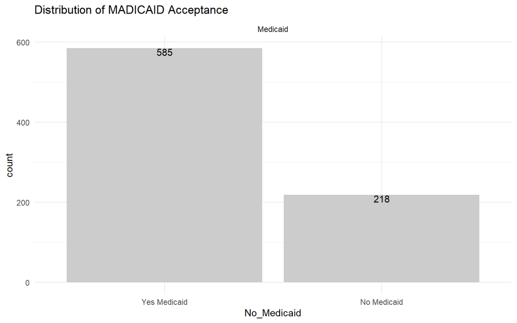

```r
med <- final2 %>%
  dplyr::filter(Reason.for.exclusions == "Physician does not accept MEDICAID") %>%
  dplyr::select(NPI) %>%
  group_by(NPI) %>%
  summarise(N = n()) %>%
  dplyr::select(-N) %>%
  mutate(No_Medicaid = 1)

final3 <- left_join(final2,med) %>%
  mutate(No_Medicaid = factor(ifelse(is.na(No_Medicaid),0,1),
                              labels= c("Yes Medicaid","No Medicaid"))) %>%
  mutate(grad = cut(Graduation.year,
                    breaks = c(1960,1986,1993,2000,2005,2012),
                    dig.lab = 0,include.lowest = TRUE)) %>%
  rename(ntransf = Number.of.Transfers..phone.call.transferred.from.one.person.or.answering.service.to.the.next.,
         reason = Reason.for.exclusions,
         days = Business.days.until.appointment,
         title = Professional.Title.Merged
         )


ggplot(dplyr::filter(final3,insurance_type == "Medicaid"),
       aes(x = No_Medicaid))+
  geom_bar(fill = "gray80")+
  geom_text(stat='count', aes(label=..count..), vjust= 1)+
  ggtitle("Distribution of MADICAID Acceptance")+
  facet_wrap(~insurance_type)+
  theme_minimal()
```

# 4 Names

The three other names shown below appear 4 times, but they have different NPI. We notice that the number of waiting days is the same, which seems strong evidence of repetition. SO, we will assume duplicaiton and remove a pair of values for each name.

```r
temp <- final3 %>%
  left_join(final3 %>%
  group_by(NPI) %>%
  summarise(n = n())) %>%
  filter(n == 4) %>%
  select(NPI,name,insurance_type,subspecialty,days) %>%
  arrange(name)

kable(temp,caption = "NPIs that appears 4 times, but have different name") %>%
  kable_styling(full_width = F)
```

NPIs that appears 4 times, but have different name

| NPI | name | insurance_type | subspecialty | days |
| --- | --- | --- | --- | --- |
| 1386620805 | Linda Sung | Blue Cross/Shield | Reprod End & Infert | NA |
| 1386620805 | Linda Sung | Medicaid | Reprod End & Infert | NA |
| 1386620805 | Ricardo Asch | Blue Cross/Shield | Reprod End & Infert | NA |
| 1386620805 | Ricardo Asch | Medicaid | Reprod End & Infert | NA |

```r
# Linda Sung and Ricardo Asch have the same NPI. We change NPI for Linda.
final3$NPI[final3$name == "Linda Sung"] <- 1386620806

temp <- final3 %>%
  left_join(final3 %>%
  group_by(name) %>%
  summarise(n = n())) %>%
  filter(n == 4) %>%
  select(NPI,name,insurance_type,subspecialty,days) %>%
  arrange(name)

kable(temp,caption = "Names that appear 4 times, but have different NPI") %>%
  kable_styling(full_width = F)
```

Names that appear 4 times, but have different NPI

| NPI | name | insurance_type | subspecialty | days |
| --- | --- | --- | --- | --- |
| 1861651143 | Bo Yu | Blue Cross/Shield | Reprod End & Infert | NA |
| 1023681210 | Bo Yu | Blue Cross/Shield | Reprod End & Infert | NA |
| 1861651143 | Bo Yu | Medicaid | Reprod End & Infert | NA |
| 1023681210 | Bo Yu | Medicaid | Reprod End & Infert | NA |
| 1235152968 | Kristin Atkins | Blue Cross/Shield | Mat-Fet Med | 11 |
| 1881616365 | Kristin Atkins | Blue Cross/Shield | Mat-Fet Med | 11 |
| 1235152968 | Kristin Atkins | Medicaid | Mat-Fet Med | 12 |
| 1881616365 | Kristin Atkins | Medicaid | Mat-Fet Med | 12 |
| 942369285 | Maria Palmquist | Blue Cross/Shield | Mat-Fet Med | 15 |
| 1942369285 | Maria Palmquist | Blue Cross/Shield | Mat-Fet Med | 15 |
| 942369285 | Maria Palmquist | Medicaid | Mat-Fet Med | 12 |
| 1942369285 | Maria Palmquist | Medicaid | Mat-Fet Med | 12 |

```r
final3 <- final3 %>%
  filter(!(NPI %in% c(1023681210,1881616365,1942369285)))
```

# 5 New Data

A new dataset was sent in 23/SEP/2021.

There is a missing NPI in the new dataset.

```r
newdata <- readRDS("sampleddata_mutate_73.rds")

newdata <- newdata %>% rename(NPI = npi)

setdiff(newdata$NPI, final3$NPI)
```

```
## [1] NA
```

And 2 NPIs in the old dataset dont appear in the new dataset.

```r
setdiff(final3$NPI, newdata$NPI)
```

```
## [1] 1043241607 1386620806
```

From the tables below we see that the differences are:

Ira Bernstein has missing NPI in the new data, so we will replace it by the NPI with same name in the old data.

Linda Sung has her NPI changed in the old data, which is why they dont match. We will change her NPI in the new data as well.

When these modifications are made, the datasets should have the same NPIs and names and can be merged. We will therefore just add the variables from the new dataset into the old dataset.

The new variables imported from the new dataset are: state, age_category, ACOG_District and Rural_Urban.

```r
t <- newdata %>% filter(NPI %in% setdiff(newdata$NPI, final3$NPI)) %>%
  select(NPI, name, gender, specialty)

kable(t, caption = "NPI in the new dataset not in the old dataset")
```

NPI in the new dataset not in the old dataset

| NPI | name | gender | specialty |
| --- | --- | --- | --- |
| NA | Ira Bernstein | Female | Maternal-Fetal Medicine |
| NA | Ira Bernstein | Female | Maternal-Fetal Medicine |

```r
t2 <- final3 %>% filter(NPI %in% setdiff(final3$NPI, newdata$NPI)) %>%
  select(NPI, name, gender, specialty)

kable(t2, caption = "NPI in the old dataset not in the new dataset")
```

NPI in the old dataset not in the new dataset

| NPI | name | gender | specialty |
| --- | --- | --- | --- |
| 1043241607 | Ira Bernstein | Female | Maternal-Fetal Medicine |
| 1386620806 | Linda Sung | Female | Reproductive Endocrinology and Infertility |
| 1043241607 | Ira Bernstein | Female | Maternal-Fetal Medicine |
| 1386620806 | Linda Sung | Female | Reproductive Endocrinology and Infertility |

```r
newdata$NPI[is.na(newdata$NPI)] <- 1043241607
newdata$NPI[newdata$name == "Linda Sung"] <- 1386620806

newdata.reduced <- newdata %>%
  select(NPI, name, insurance, state,age_category,ACOG_District,Rural_Urban)

final4 <- left_join(final3,newdata.reduced)
```

# 6 Visualizing the data

## 6.1 Days until appointment

We need to be aware that there are some outliers, although they get resolved when we use the log scale, which is the scale of the Poisson model, so things should be fine.

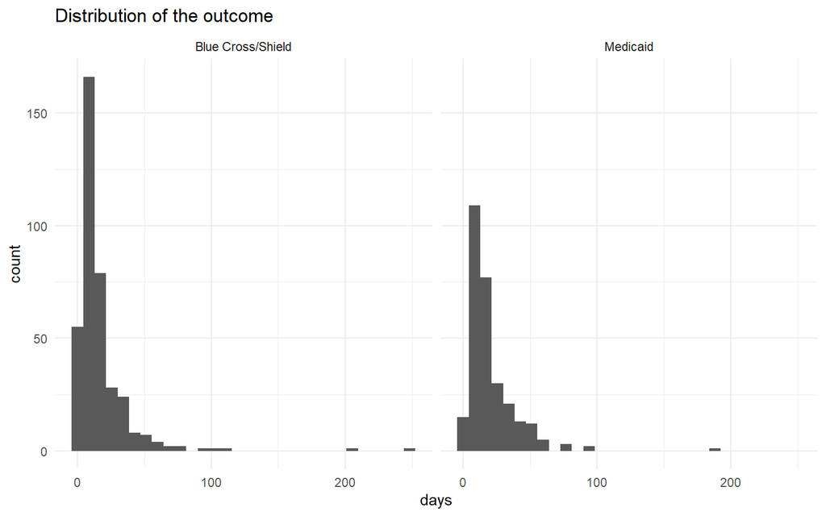

```r
ggplot(final4, aes(x = days))+
  geom_histogram()+
  facet_wrap(~insurance_type)+
  ggtitle("Distribution of the outcome")+
  theme_minimal()
```

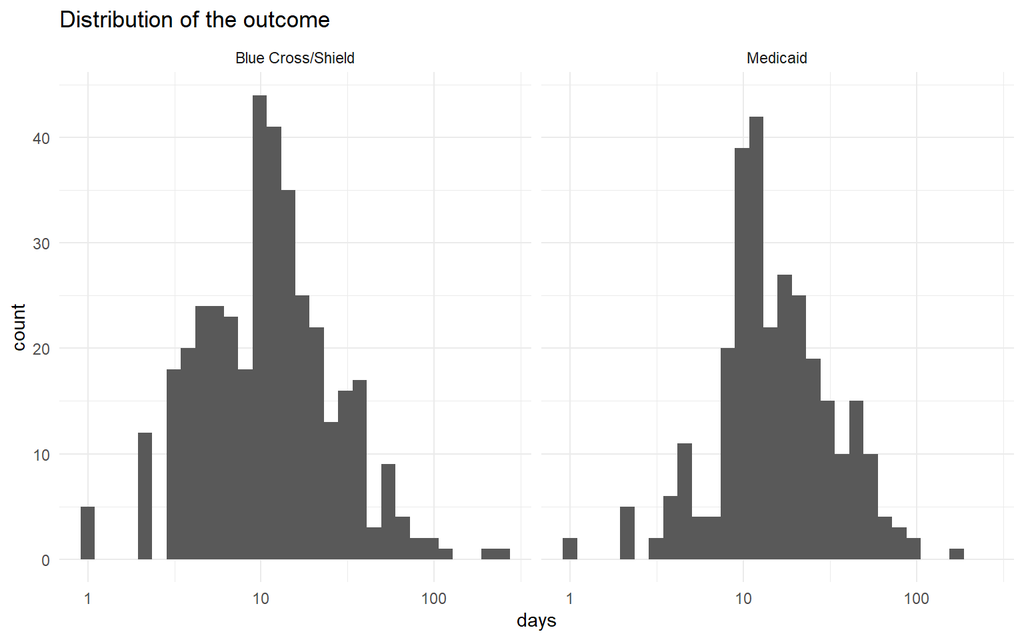

```r
ggplot(final4, aes(x = days))+
  geom_histogram()+
  facet_wrap(~insurance_type)+
  scale_x_log10()+
  ggtitle("Distribution of the outcome")+
  theme_minimal()
```

## 6.2 Subspecialty

When the values are the same in both insurance types we have a variable that does not change with insurance type.

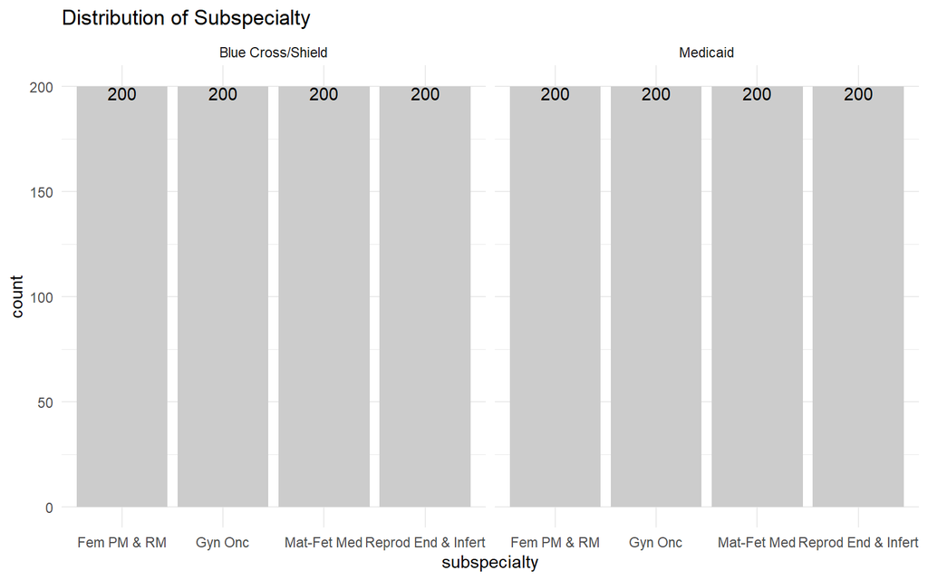

```r
ggplot(final4,
       aes(x = subspecialty))+
  geom_bar(fill = "gray80")+
  geom_text(stat='count', aes(label=..count..), vjust= 1)+
  ggtitle("Distribution of Subspecialty")+
  facet_wrap(~insurance_type)+
  theme_minimal()
```

## 6.3 Day of the Week

We have a huge imbalance in Day of the Week. What is day of week here?

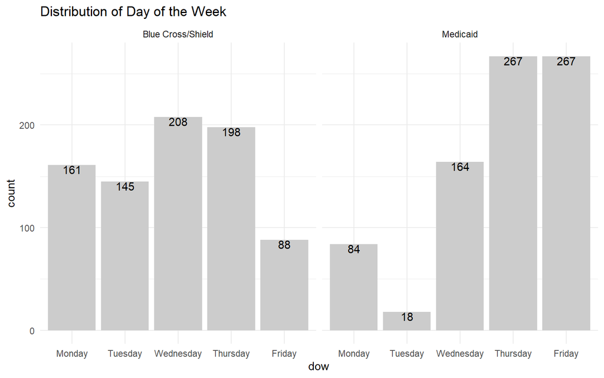

```r
ggplot(final4,
       aes(x = dow))+
  geom_bar(fill = "gray80")+
  geom_text(stat='count', aes(label=..count..), vjust= 1)+
  ggtitle("Distribution of Day of the Week")+
  facet_wrap(~insurance_type)+
  theme_minimal()
```

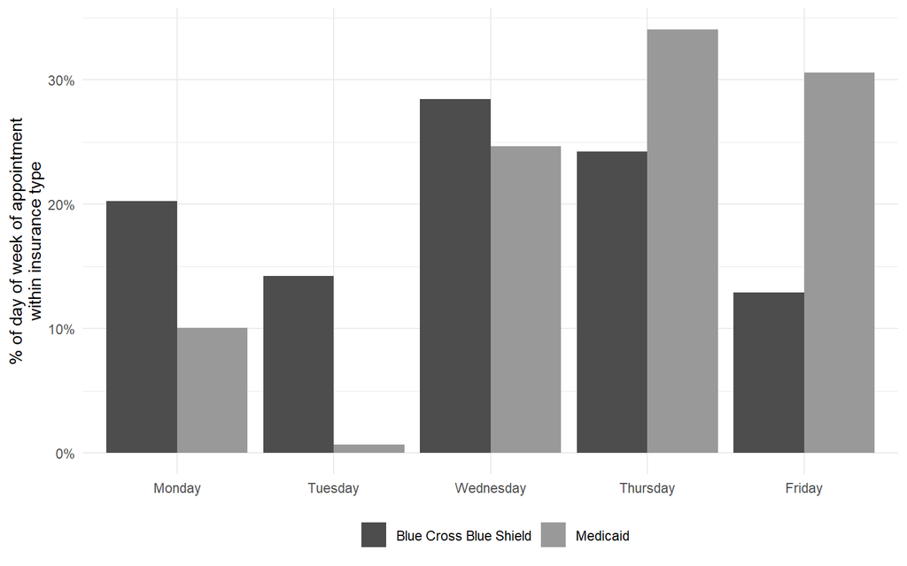

```r
tp <- final4 %>%
  filter(!is.na(days))%>%
  group_by(insurance_type, dow)%>%
  summarise(n = n())%>%
  left_join(final4 %>%
              filter(!is.na(days))%>%
              group_by(insurance_type)%>%
              summarise(ntot = n())  )%>%
  mutate(pct = n/ntot)

tp$it<- factor(tp$insurance_type, labels = c("Blue Cross Blue Shield","Medicaid"))

ggplot(tp,
       aes(x = dow, y = pct))+
  geom_bar(aes(fill = it ), stat= "identity", position = "dodge")+
  scale_y_continuous(labels = scales::percent)+
#  geom_text(aes(label=scales::percent(pct), color = insurance_type),
#            position = position_dodge(width=1), vjust=-1, size=2)+
  scale_fill_manual(name = "Insurance Type", values = c("gray30","gray60"))+
 # ggtitle("Distribution of Day of the Week")+
  ylab("% of day of week of appointment\nwithin insurance type")+
  theme_minimal()+
  theme(
    legend.position = "bottom",
    axis.title.x = element_blank(),
    legend.title = element_blank()
  )
```

```r
ggsave("Figure 3.tiff", width = 6, height = 4, dpi = 200)
```

## 6.4 Central number

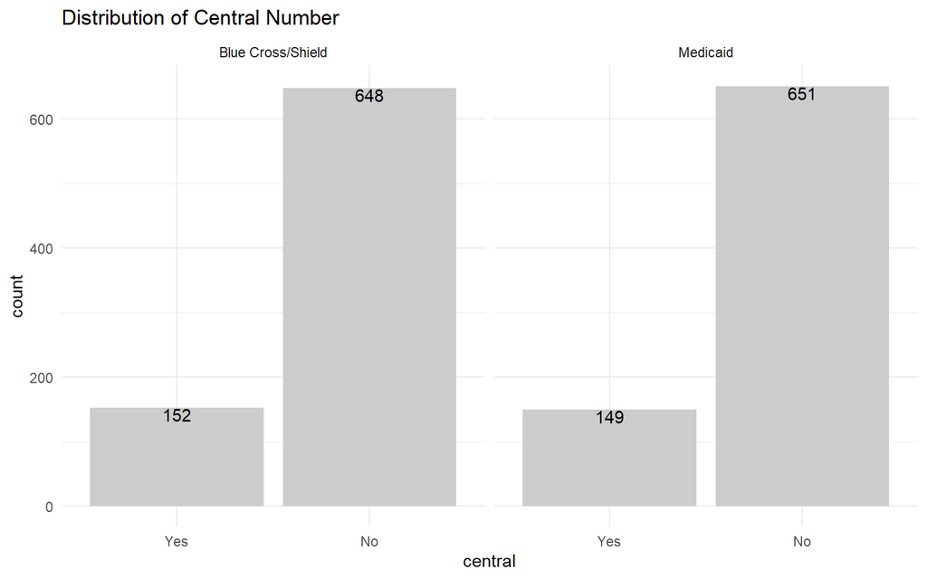

```r
ggplot(final4,
       aes(x = central))+
  geom_bar(fill = "gray80")+
  geom_text(stat='count', aes(label=..count..), vjust= 1)+
  ggtitle("Distribution of Central Number")+
  facet_wrap(~insurance_type)+
  theme_minimal()
```

## 6.5 Gender

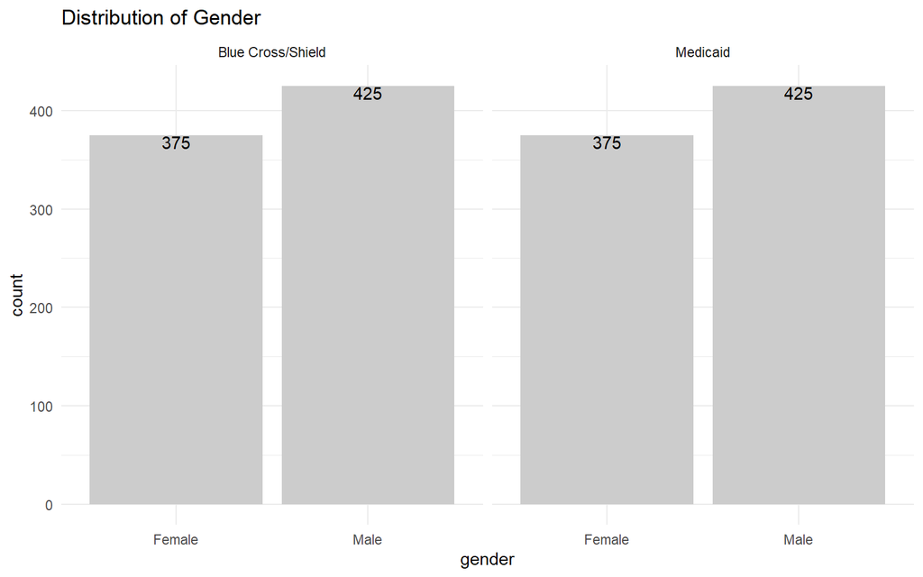

```r
ggplot(final4,
       aes(x = gender))+
  geom_bar(fill = "gray80")+
  geom_text(stat='count', aes(label=..count..), vjust= 1)+
  ggtitle("Distribution of Gender")+
  facet_wrap(~insurance_type)+
  theme_minimal()
```

## 6.6 Provider Credential Text

Need to be careful with this variable as one group is too small.

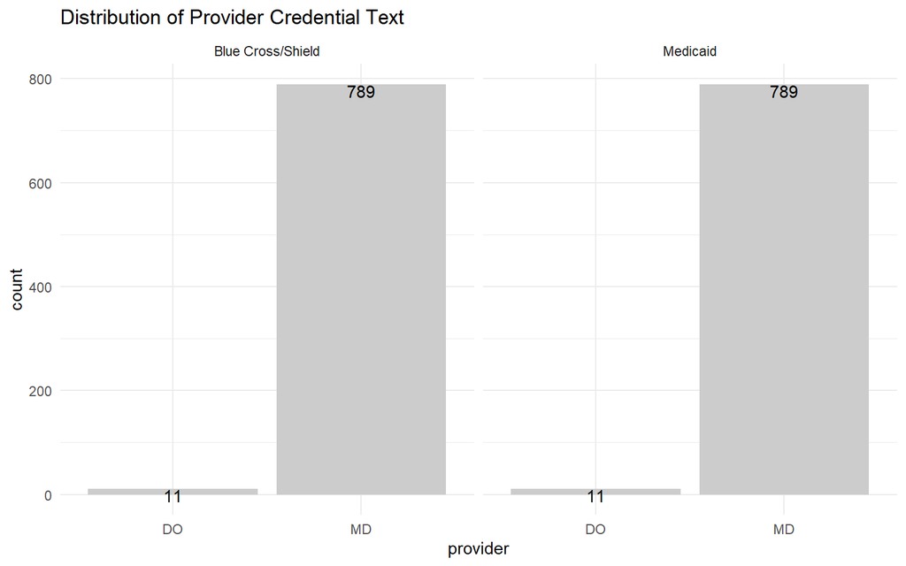

```r
ggplot(final4,
       aes(x = provider))+
  geom_bar(fill = "gray80")+
  geom_text(stat='count', aes(label=..count..), vjust= 1)+
  ggtitle("Distribution of Provider Credential Text")+
  facet_wrap(~insurance_type)+
  theme_minimal()
```

## 6.7 District

We saw that each State is in only one District, so we will use District instead of State, which has too many levels.

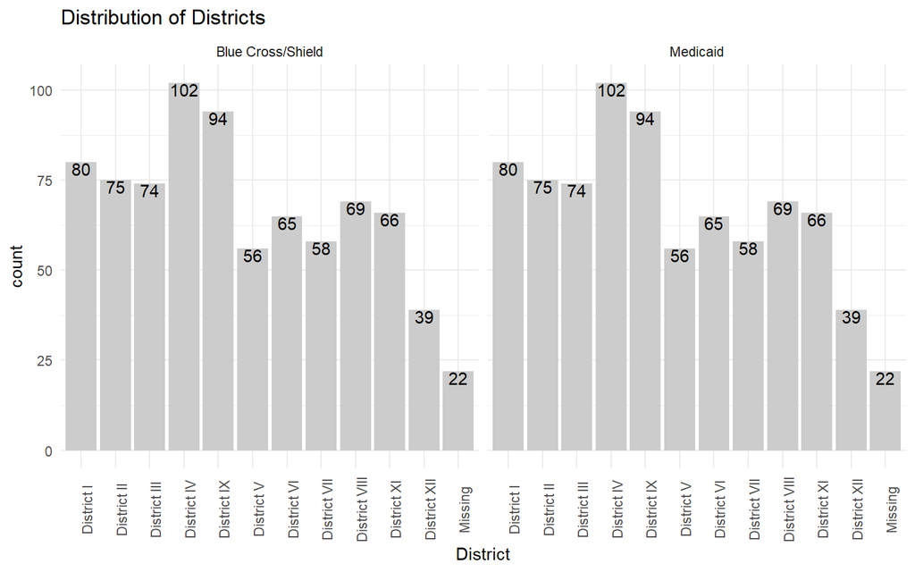

```r
final4$District <- final4$ACOG_District
final4$District[is.na(final4$District)] <- "Missing"

ggplot(final4,
       aes(x = District))+
  geom_bar(fill = "gray80")+
  geom_text(stat='count', aes(label=..count..), vjust= 1)+
  ggtitle("Distribution of Districts")+
  facet_wrap(~insurance_type)+
  theme_minimal()+
  theme(axis.text.x = element_text(angle=90))
```

## 6.8 Age Category

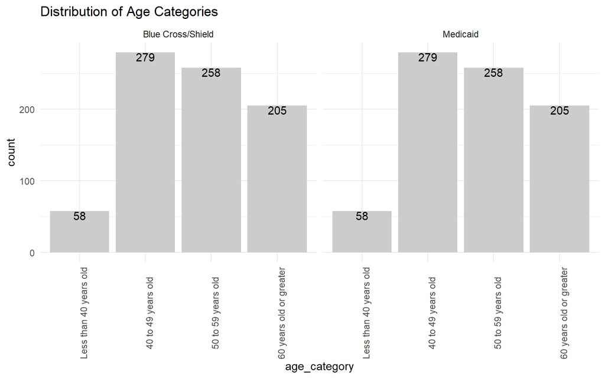

```r
ggplot(final4,
       aes(x = age_category))+
  geom_bar(fill = "gray80")+
  geom_text(stat='count', aes(label=..count..), vjust= 1)+
  ggtitle("Distribution of Age Categories")+
  facet_wrap(~insurance_type)+
  theme_minimal()+
  theme(axis.text.x = element_text(angle=90))
```

# 7 Descriptives

## 7.1 All 800 Providers

There are 800 providers in the dataset. These are all sampled providers. Many of these providers could not be contacted. In the paper we probably want to report characteristics of contacted providers who have at least one waiting time and are therefore included in the analysis.

**Total** column is at the provider level. Not meaningful with insurance specific variables, like day of the week.

**Insurance Type** columns are at the Insurance Type level. Not meaningful with provider level variables.

**MEDICAID Acceptance** columns are at the provider level. Not meaningful with insurance specific variables.

**In the Analysis** columns are at the provider level. Not meaningful with insurance specific variables. Here, *In the Analysis* means those providers that have data for number of days until appointment, and therefore will be used in the analysis. A comparison between “In the Analsyis” and “Not in the Analysis” may give an idea of bias in the data, that is, what kind of proviers were easier to reach and because of that are more represented in the sample than they should.

```r
final4.half <- filter(final4, insurance_type == "Medicaid")

temp <- final4 %>%
  left_join(final4 %>%
              group_by(NPI) %>%
              summarise(sumdays = sum(days, na.rm = T))) %>%
  mutate(contacted = 1*(sumdays > 0) ) %>%
  mutate(contact = factor(contacted, labels = c("Not in the Analysis","In the Analysis")))

# Reason for exclusion for non-contacted.
x <- temp %>% filter(contacted == 0) %>% select(NPI,reason, days) %>% arrange(NPI) %>%
  group_by(reason) %>% summarise(n = n(), pct = n/646) %>% ungroup() %>%
  arrange(desc(n))

kable(x, caption = "Reason for exclusion for non-contacted physicians") %>%
  kable_styling(full_width = F)
```

Reason for exclusion for non-contacted physicians

| reason | n | pct |
| --- | --- | --- |
| Went to voicemail | 139 | 0.2151703 |
| Physician does not accept MEDICAID | 93 | 0.1439628 |
| Physician referral required before scheduling appointment | 83 | 0.1284830 |
| Physician’s personal phone | 59 | 0.0913313 |
| Closed medical system (e.g. Kaiser or military hospital) | 50 | 0.0773994 |
| Phone not answered or busy signal on repeat calls | 50 | 0.0773994 |
| Greater than 5 minutes on hold | 43 | 0.0665635 |
| Able to contact | 42 | 0.0650155 |
| Not accepting new patients | 41 | 0.0634675 |
| Number contacted did not correspond to expected office/specialty | 41 | 0.0634675 |
| Must see midlevel before seeing physician | 5 | 0.0077399 |

```r
temp.half <- filter(temp, insurance_type == "Medicaid")


table1( x = c(list(Total = final4.half),
              split(final4.half, final4$subspecialty),
              split(final4, final4$insurance_type),
              split(final4.half, final4.half$No_Medicaid),
              split(temp.half, temp.half$contact)),
        labels = list(variables = list(gender = "Physician Gender",
                                       Age = "Physician Age in Years",
                                       age_category = "Age Category",
                                       subspecialty = "Subspecialty",
                                       provider = "Provider Credential Text",
                                       title = "Professional Title",
                                       grad = "Graduation Year",
                                       central = "Central Number",
                                       ntransf = "Number of Transfers",
                                       dow = "Day of the Week",
                                       reason = "Reason for Exclusions",
                                       days = "Business Days until Appointment",
                                       No_Medicaid = "MEDICAID Acceptance",
                                       District = "District",
                                       state = "State",
                                       Rural_Urban = "Rural or Urban"
                                       ),
                      groups = list("","Subspecialty","Insurance Type","MEDICAID Acceptance","In the Analysis")),
        groupspan = c(1,4,2,2,2) )
```

|  | Total (N=800) | Subspecialty Fem PM & RM (N=213) | Subspecialty Gyn Onc (N=197) | Subspecialty Mat-Fet Med (N=192) | Subspecialty Reprod End & Infert (N=198) | Insurance Type Blue Cross/Shield (N=800) | Insurance Type Medicaid (N=800) | MEDICAID Acceptance Yes Medicaid (N=583) | MEDICAID Acceptance No Medicaid (N=217) | In the Analysis Not in the Analysis (N=323) | In the Analysis In the Analysis (N=477) |
| --- | --- | --- | --- | --- | --- | --- | --- | --- | --- | --- | --- |
| Physician Gender |  |  |  |  |  |  |  |  |  |  |  |
| Female | 375 (46.9%) | 95 (44.6%) | 86 (43.7%) | 103 (53.6%) | 91 (46.0%) | 375 (46.9%) | 375 (46.9%) | 284 (48.7%) | 91 (41.9%) | 158 (48.9%) | 217 (45.5%) |
| Male | 425 (53.1%) | 118 (55.4%) | 111 (56.3%) | 89 (46.4%) | 107 (54.0%) | 425 (53.1%) | 425 (53.1%) | 299 (51.3%) | 126 (58.1%) | 165 (51.1%) | 260 (54.5%) |
| Physician Age in Years |  |  |  |  |  |  |  |  |  |  |  |
| Mean (SD) | 53.6 (9.99) | 50.8 (7.66) | 53.2 (10.3) | 55.1 (11.0) | 55.5 (10.2) | 53.6 (9.99) | 53.6 (9.99) | 53.5 (10.0) | 53.7 (9.96) | 54.2 (10.2) | 53.2 (9.85) |
| Median [Min, Max] | 53.0 [31.0, 92.0] | 51.0 [31.0, 71.0] | 52.0 [34.0, 86.0] | 54.5 [34.0, 92.0] | 56.0 [37.0, 88.0] | 53.0 [31.0, 92.0] | 53.0 [31.0, 92.0] | 53.0 [31.0, 92.0] | 53.0 [34.0, 86.0] | 53.0 [34.0, 88.0] | 53.0 [31.0, 92.0] |
| Age Category |  |  |  |  |  |  |  |  |  |  |  |
| Less than 40 years old | 58 (7.3%) | 19 (8.9%) | 15 (7.6%) | 15 (7.8%) | 9 (4.5%) | 58 (7.3%) | 58 (7.3%) | 44 (7.5%) | 14 (6.5%) | 21 (6.5%) | 37 (7.8%) |
| 40 to 49 years old | 279 (34.9%) | 84 (39.4%) | 70 (35.5%) | 59 (30.7%) | 66 (33.3%) | 279 (34.9%) | 279 (34.9%) | 202 (34.6%) | 77 (35.5%) | 108 (33.4%) | 171 (35.8%) |
| 50 to 59 years old | 258 (32.3%) | 81 (38.0%) | 63 (32.0%) | 58 (30.2%) | 56 (28.3%) | 258 (32.3%) | 258 (32.3%) | 192 (32.9%) | 66 (30.4%) | 99 (30.7%) | 159 (33.3%) |
| 60 years old or greater | 205 (25.6%) | 29 (13.6%) | 49 (24.9%) | 60 (31.3%) | 67 (33.8%) | 205 (25.6%) | 205 (25.6%) | 145 (24.9%) | 60 (27.6%) | 95 (29.4%) | 110 (23.1%) |
| Subspecialty |  |  |  |  |  |  |  |  |  |  |  |
| Fem PM & RM | 200 (25.0%) | 200 (93.9%) | 0 (0%) | 0 (0%) | 0 (0%) | 200 (25.0%) | 200 (25.0%) | 165 (28.3%) | 35 (16.1%) | 38 (11.8%) | 162 (34.0%) |
| Gyn Onc | 200 (25.0%) | 3 (1.4%) | 197 (100%) | 0 (0%) | 0 (0%) | 200 (25.0%) | 200 (25.0%) | 143 (24.5%) | 57 (26.3%) | 74 (22.9%) | 126 (26.4%) |
| Mat-Fet Med | 200 (25.0%) | 8 (3.8%) | 0 (0%) | 192 (100%) | 0 (0%) | 200 (25.0%) | 200 (25.0%) | 177 (30.4%) | 23 (10.6%) | 98 (30.3%) | 102 (21.4%) |
| Reprod End & Infert | 200 (25.0%) | 2 (0.9%) | 0 (0%) | 0 (0%) | 198 (100%) | 200 (25.0%) | 200 (25.0%) | 98 (16.8%) | 102 (47.0%) | 113 (35.0%) | 87 (18.2%) |
| Provider Credential Text |  |  |  |  |  |  |  |  |  |  |  |
| DO | 11 (1.4%) | 3 (1.4%) | 1 (0.5%) | 5 (2.6%) | 2 (1.0%) | 11 (1.4%) | 11 (1.4%) | 9 (1.5%) | 2 (0.9%) | 3 (0.9%) | 8 (1.7%) |
| MD | 789 (98.6%) | 210 (98.6%) | 196 (99.5%) | 187 (97.4%) | 196 (99.0%) | 789 (98.6%) | 789 (98.6%) | 574 (98.5%) | 215 (99.1%) | 320 (99.1%) | 469 (98.3%) |
| Professional Title |  |  |  |  |  |  |  |  |  |  |  |
| Academics | 314 (39.3%) | 71 (33.3%) | 89 (45.2%) | 78 (40.6%) | 76 (38.4%) | 314 (39.3%) | 314 (39.3%) | 237 (40.7%) | 77 (35.5%) | 137 (42.4%) | 177 (37.1%) |
| Not academics | 486 (60.8%) | 142 (66.7%) | 108 (54.8%) | 114 (59.4%) | 122 (61.6%) | 486 (60.8%) | 486 (60.8%) | 346 (59.3%) | 140 (64.5%) | 186 (57.6%) | 300 (62.9%) |
| Graduation Year |  |  |  |  |  |  |  |  |  |  |  |
| [1960,1986] | 116 (14.5%) | 24 (11.3%) | 39 (19.8%) | 40 (20.8%) | 13 (6.6%) | 116 (14.5%) | 116 (14.5%) | 90 (15.4%) | 26 (12.0%) | 47 (14.6%) | 69 (14.5%) |
| (1986,1993] | 111 (13.9%) | 39 (18.3%) | 35 (17.8%) | 26 (13.5%) | 11 (5.6%) | 111 (13.9%) | 111 (13.9%) | 89 (15.3%) | 22 (10.1%) | 34 (10.5%) | 77 (16.1%) |
| (1993,2000] | 139 (17.4%) | 56 (26.3%) | 45 (22.8%) | 27 (14.1%) | 11 (5.6%) | 139 (17.4%) | 139 (17.4%) | 108 (18.5%) | 31 (14.3%) | 51 (15.8%) | 88 (18.4%) |
| (2000,2005] | 110 (13.8%) | 42 (19.7%) | 38 (19.3%) | 28 (14.6%) | 2 (1.0%) | 110 (13.8%) | 110 (13.8%) | 83 (14.2%) | 27 (12.4%) | 35 (10.8%) | 75 (15.7%) |
| (2005,2012] | 85 (10.6%) | 28 (13.1%) | 28 (14.2%) | 27 (14.1%) | 2 (1.0%) | 85 (10.6%) | 85 (10.6%) | 72 (12.4%) | 13 (6.0%) | 31 (9.6%) | 54 (11.3%) |
| Missing | 239 (29.9%) | 24 (11.3%) | 12 (6.1%) | 44 (22.9%) | 159 (80.3%) | 239 (29.9%) | 239 (29.9%) | 141 (24.2%) | 98 (45.2%) | 125 (38.7%) | 114 (23.9%) |
| Central Number |  |  |  |  |  |  |  |  |  |  |  |

[output cut: 101 more lines]

## 7.2 477 Providers in the Analysis

323 providers will be removed from the analysis because they did not provide any waiting time (the models automatically remove them). So, in the paper, we probably should remove these providers from the descriptive table. The table below dont have these providers.

**Caution** The table below is not valid for variables that change with insurrance type, like Day of the Week.

```r
temp <- final4 %>%
  left_join(final4 %>%
              group_by(NPI) %>%
              summarise(sumdays = sum(days, na.rm = T))) %>%
  filter(sumdays > 0)

temp.half <- filter(temp, insurance_type == "Medicaid")

table1( x = c(list(Total = temp.half),
              split(temp, temp$insurance_type),
              split(temp.half, temp.half$No_Medicaid )),
        labels = list(variables = list(gender = "Physician Gender",
                                       Age = "Physician Age in Years",
                                       age_category = "Age Category",
                                       subspecialty = "Subspecialty",
                                       provider = "Provider Credential Text",
                                       title = "Professional Title",
                                       grad = "Graduation Year",
                                       central = "Central Number",
                                       ntransf = "Number of Transfers",
                                       dow = "Day of the Week",
                                       reason = "Reason for Exclusions",
                                       days = "Business Days until Appointment",
                                       No_Medicaid = "MEDICAID Acceptance",
                                       District = "District",
                                       state = "State",
                                       Rural_Urban = "Rural or Urban"                                                                  ),
                      groups = list("","Insurance Type","MEDICAID Acceptance")),
        groupspan = c(1,2,2) )
```

|  | Total (N=477) | Insurance Type Blue Cross/Shield (N=477) | Insurance Type Medicaid (N=477) | MEDICAID Acceptance Yes Medicaid (N=354) | MEDICAID Acceptance No Medicaid (N=123) |
| --- | --- | --- | --- | --- | --- |
| Physician Gender |  |  |  |  |  |
| Female | 217 (45.5%) | 217 (45.5%) | 217 (45.5%) | 172 (48.6%) | 45 (36.6%) |
| Male | 260 (54.5%) | 260 (54.5%) | 260 (54.5%) | 182 (51.4%) | 78 (63.4%) |
| Physician Age in Years |  |  |  |  |  |
| Mean (SD) | 53.2 (9.85) | 53.2 (9.85) | 53.2 (9.85) | 52.9 (9.81) | 53.9 (9.95) |
| Median [Min, Max] | 53.0 [31.0, 92.0] | 53.0 [31.0, 92.0] | 53.0 [31.0, 92.0] | 52.5 [31.0, 92.0] | 53.0 [34.0, 86.0] |
| Age Category |  |  |  |  |  |
| Less than 40 years old | 37 (7.8%) | 37 (7.8%) | 37 (7.8%) | 29 (8.2%) | 8 (6.5%) |
| 40 to 49 years old | 171 (35.8%) | 171 (35.8%) | 171 (35.8%) | 128 (36.2%) | 43 (35.0%) |
| 50 to 59 years old | 159 (33.3%) | 159 (33.3%) | 159 (33.3%) | 119 (33.6%) | 40 (32.5%) |
| 60 years old or greater | 110 (23.1%) | 110 (23.1%) | 110 (23.1%) | 78 (22.0%) | 32 (26.0%) |
| Subspecialty |  |  |  |  |  |
| Fem PM & RM | 162 (34.0%) | 162 (34.0%) | 162 (34.0%) | 131 (37.0%) | 31 (25.2%) |
| Gyn Onc | 126 (26.4%) | 126 (26.4%) | 126 (26.4%) | 104 (29.4%) | 22 (17.9%) |
| Mat-Fet Med | 102 (21.4%) | 102 (21.4%) | 102 (21.4%) | 84 (23.7%) | 18 (14.6%) |
| Reprod End & Infert | 87 (18.2%) | 87 (18.2%) | 87 (18.2%) | 35 (9.9%) | 52 (42.3%) |
| Provider Credential Text |  |  |  |  |  |
| DO | 8 (1.7%) | 8 (1.7%) | 8 (1.7%) | 7 (2.0%) | 1 (0.8%) |
| MD | 469 (98.3%) | 469 (98.3%) | 469 (98.3%) | 347 (98.0%) | 122 (99.2%) |
| Professional Title |  |  |  |  |  |
| Academics | 177 (37.1%) | 177 (37.1%) | 177 (37.1%) | 142 (40.1%) | 35 (28.5%) |
| Not academics | 300 (62.9%) | 300 (62.9%) | 300 (62.9%) | 212 (59.9%) | 88 (71.5%) |
| Graduation Year |  |  |  |  |  |
| [1960,1986] | 69 (14.5%) | 69 (14.5%) | 69 (14.5%) | 54 (15.3%) | 15 (12.2%) |
| (1986,1993] | 77 (16.1%) | 77 (16.1%) | 77 (16.1%) | 63 (17.8%) | 14 (11.4%) |
| (1993,2000] | 88 (18.4%) | 88 (18.4%) | 88 (18.4%) | 70 (19.8%) | 18 (14.6%) |
| (2000,2005] | 75 (15.7%) | 75 (15.7%) | 75 (15.7%) | 59 (16.7%) | 16 (13.0%) |
| (2005,2012] | 54 (11.3%) | 54 (11.3%) | 54 (11.3%) | 50 (14.1%) | 4 (3.3%) |
| Missing | 114 (23.9%) | 114 (23.9%) | 114 (23.9%) | 58 (16.4%) | 56 (45.5%) |
| Central Number |  |  |  |  |  |

[output cut: 99 more lines]

Table for insurance type.

```r
temp <- final4 %>%
  left_join(final4 %>%
              group_by(NPI) %>%
              summarise(sumdays = sum(days, na.rm = T))) %>%
  filter(sumdays > 0) %>%
  filter(!is.na(days))

temp.half <- filter(temp, insurance_type == "Medicaid")

table1( x = c(list(Total = temp),
              split(temp, temp$insurance_type) ),
        labels = list(variables = list(gender = "Physician Gender",
                                       Age = "Physician Age in Years",
                                       age_category = "Age Category",
                                       subspecialty = "Subspecialty",
                                       provider = "Provider Credential Text",
                                       title = "Professional Title",
                                       grad = "Graduation Year",
                                       central = "Central Number",
                                       ntransf = "Number of Transfers",
                                       dow = "Day of the Week",
                                       reason = "Reason for Exclusions",
                                       days = "Business Days until Appointment",
                                       No_Medicaid = "MEDICAID Acceptance",
                                       District = "District",
                                       state = "State",
                                       Rural_Urban = "Rural or Urban"                                                                  ),
                      groups = list("","Insurance Type" )),
        groupspan = c(1,2) )
```

|  | Total (N=668) | Insurance Type Blue Cross/Shield (N=380) | Insurance Type Medicaid (N=288) |
| --- | --- | --- | --- |
| Physician Gender |  |  |  |
| Female | 306 (45.8%) | 178 (46.8%) | 128 (44.4%) |
| Male | 362 (54.2%) | 202 (53.2%) | 160 (55.6%) |
| Physician Age in Years |  |  |  |
| Mean (SD) | 53.0 (9.54) | 52.7 (9.31) | 53.4 (9.84) |
| Median [Min, Max] | 53.0 [31.0, 92.0] | 52.0 [31.0, 86.0] | 53.0 [31.0, 92.0] |
| Age Category |  |  |  |
| Less than 40 years old | 50 (7.5%) | 31 (8.2%) | 19 (6.6%) |
| 40 to 49 years old | 243 (36.4%) | 141 (37.1%) | 102 (35.4%) |
| 50 to 59 years old | 223 (33.4%) | 122 (32.1%) | 101 (35.1%) |
| 60 years old or greater | 152 (22.8%) | 86 (22.6%) | 66 (22.9%) |
| Subspecialty |  |  |  |
| Fem PM & RM | 255 (38.2%) | 146 (38.4%) | 109 (37.8%) |
| Gyn Onc | 167 (25.0%) | 77 (20.3%) | 90 (31.3%) |
| Mat-Fet Med | 141 (21.1%) | 90 (23.7%) | 51 (17.7%) |
| Reprod End & Infert | 105 (15.7%) | 67 (17.6%) | 38 (13.2%) |
| Provider Credential Text |  |  |  |
| DO | 12 (1.8%) | 8 (2.1%) | 4 (1.4%) |
| MD | 656 (98.2%) | 372 (97.9%) | 284 (98.6%) |
| Professional Title |  |  |  |
| Academics | 254 (38.0%) | 136 (35.8%) | 118 (41.0%) |
| Not academics | 414 (62.0%) | 244 (64.2%) | 170 (59.0%) |
| Graduation Year |  |  |  |
| [1960,1986] | 98 (14.7%) | 54 (14.2%) | 44 (15.3%) |
| (1986,1993] | 112 (16.8%) | 62 (16.3%) | 50 (17.4%) |
| (1993,2000] | 120 (18.0%) | 67 (17.6%) | 53 (18.4%) |
| (2000,2005] | 109 (16.3%) | 62 (16.3%) | 47 (16.3%) |
| (2005,2012] | 79 (11.8%) | 42 (11.1%) | 37 (12.8%) |
| Missing | 150 (22.5%) | 93 (24.5%) | 57 (19.8%) |
| Central Number |  |  |  |

[output cut: 95 more lines]

### 7.2.1 Statistical Tests

Here we conduct statistical tests to see if the profile differs for those who accept Medicaid and those who dont. This analysis is only valid for variables that dont change with insurance type. It is not valid for variables that change, like Day of the Week.

```r
# temp is the dataset with only contacted providers.
blong <- filter(temp, insurance_type == "Medicaid")

vars <- c("gender","Age","age_category","subspecialty","provider","title","grad","central",
          "ntransf","dow","reason","District")

testdata <- data.frame(variable = character(), test = character(), p.value = double())
for (i in vars){
  p <- sum((names(blong) == i)*(seq(1,ncol(blong))))
  #print(paste0("Variable = ",i,", Position =",p ))
  if (is.numeric(blong[[p]])){
    w <- wilcox.test(blong[[p]] ~ blong$No_Medicaid)
    temp2 <- data.frame(variable = i,test = "Wilcox",p.value = w$p.value)
  } else{
    w <- fisher.test(blong[[p]] , blong$No_Medicaid, simulate.p.value = T, B=100000)
    temp2 <- data.frame(variable = i,test = "Fisher",p.value = w$p.value)
  }

testdata <- rbind(testdata,temp2)

}

kable(testdata, caption = "p-values for association between Accepting Medicaid and other variables in the dataset") %>%
  kable_styling(full_width = FALSE)
```

p-values for association between Accepting Medicaid and other variables in the dataset

| variable | test | p.value |
| --- | --- | --- |
| gender | Fisher | 0.1360222 |
| Age | Wilcox | 0.1078885 |
| age_category | Fisher | 0.3539965 |
| subspecialty | Fisher | 0.0000100 |
| provider | Fisher | 1.0000000 |
| title | Fisher | 0.2801499 |
| grad | Fisher | 0.8176618 |
| central | Fisher | 0.6155119 |
| ntransf | Fisher | 0.0034100 |
| dow | Fisher | 0.2736673 |
| reason | Fisher | 0.0000100 |
| District | Fisher | 0.6142239 |

### 7.2.2 Association Physician Age and Medicaid Acceptance

This is related to reviewer request in the second revision.

```r
# Age in Years - Mann-Whitney non-parametric test
wilcox.test(temp.half$Age ~ temp.half$No_Medicaid)
```

```
##
##  Wilcoxon rank sum test with continuity correction
##
## data:  temp.half$Age by temp.half$No_Medicaid
## W = 2540, p-value = 0.1079
## alternative hypothesis: true location shift is not equal to 0
```

```r
# Age Groups - Fisher Test.
fisher.test(temp.half$age_category, temp.half$No_Medicaid)
```

```
##
##  Fisher's Exact Test for Count Data
##
## data:  temp.half$age_category and temp.half$No_Medicaid
## p-value = 0.3533
## alternative hypothesis: two.sided
```

## 7.3 In the Analysis x Not in the Analysis

Here we compare the providers in the analysis because they have some data available and the ones that are excluded from the analysis. Assuming that the “Total” column is representative, we can have an idea if the analyzed providers are skewed.

**Caution** - Some variables like “Day of the Week” varies with Insurance type and should not be looked at. For this table we selected only the Insurance Type Medicaid.

```r
final4 <- final4 %>%
  left_join(temp %>%
              group_by(NPI) %>%
              summarise(n = n()) %>%
              mutate(nodata = 1) %>%
              select(-n))

final4$nodata[is.na(final4$nodata)]<- 0
final4$nodata <- factor(final4$nodata, labels = c("Not in the Analysis",
                                                  "In the Analysis"))

label(final4$nodata) <- "Providers in the Anaysis"

final4.half <- filter(final4, insurance_type == "Medicaid")

table1( x = c(list(Total = final4.half),
              split(final4.half,  final4.half$nodata) ),
        labels = list(variables = list(gender = "Physician Gender",
                                       Age = "Physician Age in Years",
                                       age_category = "Age Category",
                                       subspecialty = "Subspecialty",
                                       provider = "Provider Credential Text",
                                       title = "Professional Title",
                                       grad = "Graduation Year",
                                       central = "Central Number",
                                       ntransf = "Number of Transfers",
                                       dow = "Day of the Week",
                                       reason = "Reason for Exclusions",
                                       days = "Business Days until Appointment",
                                       No_Medicaid = "MEDICAID Acceptance",
                                       District = "District",
                                       state = "State",
                                       Rural_Urban = "Rural or Urban"
                                       ),
                      groups = list("","Analysis Status")),
        groupspan = c(1,2) )
```

|  | Total (N=800) | Analysis Status Not in the Analysis (N=323) | Analysis Status In the Analysis (N=477) |
| --- | --- | --- | --- |
| Physician Gender |  |  |  |
| Female | 375 (46.9%) | 158 (48.9%) | 217 (45.5%) |
| Male | 425 (53.1%) | 165 (51.1%) | 260 (54.5%) |
| Physician Age in Years |  |  |  |
| Mean (SD) | 53.6 (9.99) | 54.2 (10.2) | 53.2 (9.85) |
| Median [Min, Max] | 53.0 [31.0, 92.0] | 53.0 [34.0, 88.0] | 53.0 [31.0, 92.0] |
| Age Category |  |  |  |
| Less than 40 years old | 58 (7.3%) | 21 (6.5%) | 37 (7.8%) |
| 40 to 49 years old | 279 (34.9%) | 108 (33.4%) | 171 (35.8%) |
| 50 to 59 years old | 258 (32.3%) | 99 (30.7%) | 159 (33.3%) |
| 60 years old or greater | 205 (25.6%) | 95 (29.4%) | 110 (23.1%) |
| Subspecialty |  |  |  |
| Fem PM & RM | 200 (25.0%) | 38 (11.8%) | 162 (34.0%) |
| Gyn Onc | 200 (25.0%) | 74 (22.9%) | 126 (26.4%) |
| Mat-Fet Med | 200 (25.0%) | 98 (30.3%) | 102 (21.4%) |
| Reprod End & Infert | 200 (25.0%) | 113 (35.0%) | 87 (18.2%) |
| Provider Credential Text |  |  |  |
| DO | 11 (1.4%) | 3 (0.9%) | 8 (1.7%) |
| MD | 789 (98.6%) | 320 (99.1%) | 469 (98.3%) |
| Professional Title |  |  |  |
| Academics | 314 (39.3%) | 137 (42.4%) | 177 (37.1%) |
| Not academics | 486 (60.8%) | 186 (57.6%) | 300 (62.9%) |
| Graduation Year |  |  |  |
| [1960,1986] | 116 (14.5%) | 47 (14.6%) | 69 (14.5%) |
| (1986,1993] | 111 (13.9%) | 34 (10.5%) | 77 (16.1%) |
| (1993,2000] | 139 (17.4%) | 51 (15.8%) | 88 (18.4%) |
| (2000,2005] | 110 (13.8%) | 35 (10.8%) | 75 (15.7%) |
| (2005,2012] | 85 (10.6%) | 31 (9.6%) | 54 (11.3%) |
| Missing | 239 (29.9%) | 125 (38.7%) | 114 (23.9%) |
| Central Number |  |  |  |

[output cut: 101 more lines]

### 7.3.1 Statistical Test

These are statistical tests requested by Review 2 in the second revision.

```r
blong <- final4.half
vars <- c("gender","Age","age_category","subspecialty","provider","title","grad",
          "central","ntransf","District")

testdata2 <- data.frame(variable = character(), test = character(), p.value = double())
for (i in vars){
  p <- sum((names(blong) == i)*(seq(1,ncol(blong))))
  #print(paste0("Variable = ",i,", Position =",p ))
  if (is.numeric(blong[[p]])){
    w <- wilcox.test(blong[[p]] ~ blong$No_Medicaid)
    temp2 <- data.frame(variable = i,test = "Wilcox",p.value = w$p.value)
  } else{
    w <- fisher.test(blong[[p]] , blong$No_Medicaid, simulate.p.value = T, B=100000)
    temp2 <- data.frame(variable = i,test = "Fisher",p.value = w$p.value)
  }

testdata2 <- rbind(testdata2,temp2)

}

kable(testdata2, caption = "p-values for comparison of physician in the analysis and not in the analysis") %>%
  kable_styling(full_width = FALSE)
```

| variable | test | p.value |
| --- | --- | --- |
| gender | Fisher | 0.0944911 |
| Age | Wilcox | 0.7566436 |
| age_category | Fisher | 0.7967520 |
| subspecialty | Fisher | 0.0000100 |
| provider | Fisher | 0.7362238 |
| title | Fisher | 0.1932775 |
| grad | Fisher | 0.5829642 |
| central | Fisher | 0.4754404 |
| ntransf | Fisher | 0.0003000 |
| District | Fisher | 0.0000900 |

## 7.4 In the Analysis x Not in the Analysis

The same table above, but for physician varying variables.

```r
table1( x = c(list(Total = final4),
              split(final4,  final4$nodata) ),
        labels = list(variables = list(gender = "Physician Gender",
                                       Age = "Physician Age in Years",
                                       age_category = "Age Category",
                                       subspecialty = "Subspecialty",
                                       provider = "Provider Credential Text",
                                       title = "Professional Title",
                                       grad = "Graduation Year",
                                       central = "Central Number",
                                       ntransf = "Number of Transfers",
                                       dow = "Day of the Week",
                                       reason = "Reason for Exclusions",
                                       days = "Business Days until Appointment",
                                       No_Medicaid = "MEDICAID Acceptance",
                                       District = "District",
                                       state = "State",
                                       Rural_Urban = "Rural or Urban"
                                       ),
                      groups = list("","Analysis Status")),
        groupspan = c(1,2) )
```

|  | Total (N=1600) | Analysis Status Not in the Analysis (N=646) | Analysis Status In the Analysis (N=954) |
| --- | --- | --- | --- |
| Physician Gender |  |  |  |
| Female | 750 (46.9%) | 316 (48.9%) | 434 (45.5%) |
| Male | 850 (53.1%) | 330 (51.1%) | 520 (54.5%) |
| Physician Age in Years |  |  |  |
| Mean (SD) | 53.6 (9.99) | 54.2 (10.2) | 53.2 (9.84) |
| Median [Min, Max] | 53.0 [31.0, 92.0] | 53.0 [34.0, 88.0] | 53.0 [31.0, 92.0] |
| Age Category |  |  |  |
| Less than 40 years old | 116 (7.3%) | 42 (6.5%) | 74 (7.8%) |
| 40 to 49 years old | 558 (34.9%) | 216 (33.4%) | 342 (35.8%) |
| 50 to 59 years old | 516 (32.3%) | 198 (30.7%) | 318 (33.3%) |
| 60 years old or greater | 410 (25.6%) | 190 (29.4%) | 220 (23.1%) |
| Subspecialty |  |  |  |
| Fem PM & RM | 400 (25.0%) | 76 (11.8%) | 324 (34.0%) |
| Gyn Onc | 400 (25.0%) | 148 (22.9%) | 252 (26.4%) |
| Mat-Fet Med | 400 (25.0%) | 196 (30.3%) | 204 (21.4%) |
| Reprod End & Infert | 400 (25.0%) | 226 (35.0%) | 174 (18.2%) |
| Provider Credential Text |  |  |  |
| DO | 22 (1.4%) | 6 (0.9%) | 16 (1.7%) |
| MD | 1578 (98.6%) | 640 (99.1%) | 938 (98.3%) |
| Professional Title |  |  |  |
| Academics | 628 (39.3%) | 274 (42.4%) | 354 (37.1%) |
| Not academics | 972 (60.8%) | 372 (57.6%) | 600 (62.9%) |
| Graduation Year |  |  |  |
| [1960,1986] | 232 (14.5%) | 94 (14.6%) | 138 (14.5%) |
| (1986,1993] | 222 (13.9%) | 68 (10.5%) | 154 (16.1%) |
| (1993,2000] | 278 (17.4%) | 102 (15.8%) | 176 (18.4%) |
| (2000,2005] | 220 (13.8%) | 70 (10.8%) | 150 (15.7%) |
| (2005,2012] | 170 (10.6%) | 62 (9.6%) | 108 (11.3%) |
| Missing | 478 (29.9%) | 250 (38.7%) | 228 (23.9%) |
| Central Number |  |  |  |

[output cut: 101 more lines]

### 7.4.1 Statistical Tests

```r
blong <- filter(final4, insurance_type == "Medicaid")

vars <- c("gender","Age","age_category","subspecialty","provider","title","grad","central",
          "ntransf","dow","reason","District")

testdata <- data.frame(variable = character(), test = character(), p.value = double())
for (i in vars){
  p <- sum((names(blong) == i)*(seq(1,ncol(blong))))
  #print(paste0("Variable = ",i,", Position =",p ))
  if (is.numeric(blong[[p]])){
    w <- wilcox.test(blong[[p]] ~ blong$nodata)
    temp2 <- data.frame(variable = i,test = "Wilcox",p.value = w$p.value)
  } else{
    w <- fisher.test(blong[[p]] , blong$nodata, simulate.p.value = T, B=100000)
    temp2 <- data.frame(variable = i,test = "Fisher",p.value = w$p.value)
  }

testdata <- rbind(testdata,temp2)

}

kable(testdata, caption = "p-values for association between variables and outcome being available") %>%
  kable_styling(full_width = FALSE)
```

p-values for association between variables and outcome being available

| variable | test | p.value |
| --- | --- | --- |
| gender | Fisher | 0.3487580 |
| Age | Wilcox | 0.1424396 |
| age_category | Fisher | 0.2466575 |
| subspecialty | Fisher | 0.0000100 |
| provider | Fisher | 0.5394460 |
| title | Fisher | 0.1402825 |
| grad | Fisher | 0.5304147 |
| central | Fisher | 0.9263017 |
| ntransf | Fisher | 0.2401876 |
| dow | Fisher | 0.1566984 |
| reason | Fisher | 0.0000100 |
| District | Fisher | 0.0080099 |

# 8 Model Full Data

Here we will look at all providers for whom waiting time data is available.

There are 477 such providers (In total, the data has 800 providers from whom 323 has no waiting time data and are removed). These 477 providers have 668 data points (valid waiting times in the dataset)

## 8.1 Graphs

Here we try to visualize the waiting time for each insurance type, linking the providers by a line. We see that lines hardly go down from the private insurance to Medicaid (Medicaid times are hardly shorter).

**NOTE** - Isolated points without lines are providers that have data for only one insurance type. These providers are used in the analysis so we think they should be kept in the graph.

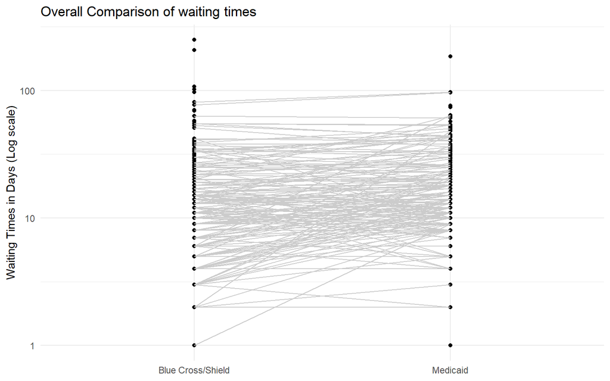

```r
ggplot(final4, aes(x = insurance_type, y = days))+
  geom_point()+
  geom_line(aes(group = NPI), color = "gray80")+
  ggtitle("Overall Comparison of waiting times")+
  ylab("Waiting Times in Days (Log scale)")+
  scale_y_log10()+
  theme_minimal()+
  theme(
    axis.title.x = element_blank()
  )
```

Here we show a scatterplot that compares the Private and Medicaid times. Notice that the graph is in logarithmic scale. Points above the diagonal line are providers for whom the Medicaid waiting time was longer than the private insurance waiting time.

We also see a strong linear association, indicating that providers with longer waiting time for private insurance tend to also have longer waiting times for Medicaid.

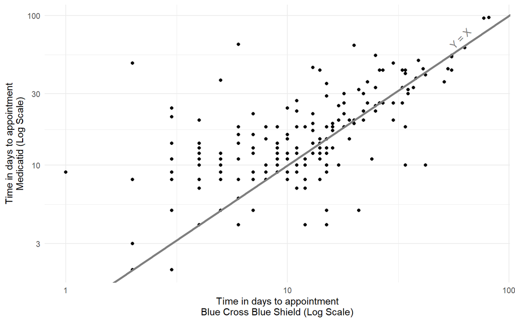

```r
temp <- tidyr::spread(final4 %>%
                        select(NPI,insurance_type,days),
                      key = insurance_type, value = days) %>%
  filter(!is.na(Medicaid), !is.na(`Blue Cross/Shield`))

ggplot(temp, aes(x = `Blue Cross/Shield`, y = Medicaid))+
  geom_point()+
  geom_abline(size = 1.1, color = "gray50")+
  #stat_smooth(method = "lm")+
  scale_x_log10()+
  scale_y_log10()+
  annotate(geom = "text", x= 60,y=70, label = "Y = X", angle = 45, color = "gray50")+
  ylab("Time in days to appointment\nMedicatid (Log Scale)")+
  xlab("Time in days to appointment\nBlue Cross Blue Shield (Log Scale)")+
  theme_minimal()
```

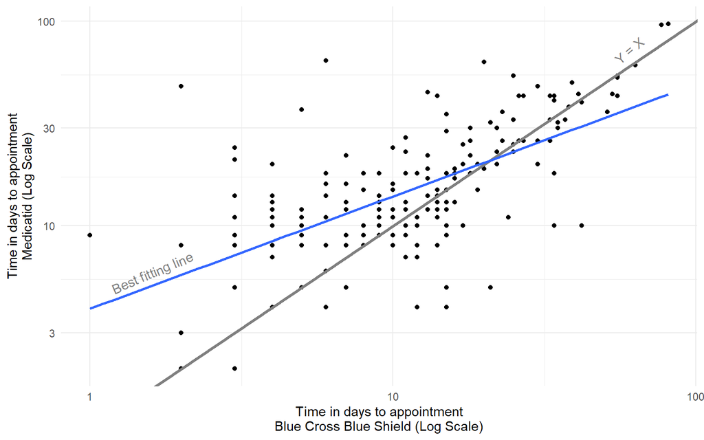

```r
ggsave("Figure 2.tiff", height = 5, width = 7, dpi = 200)


ggplot(temp, aes(x = `Blue Cross/Shield`, y = Medicaid))+
  geom_point()+
  geom_abline(size = 1.1, color = "gray50")+
  stat_smooth(method = "lm", se = F)+
  scale_x_log10()+
  scale_y_log10()+
  annotate(geom = "text", x= 60,y=72, label = "Y = X", angle = 40, color = "gray50")+
  annotate(geom = "text", x= 1.6,y=5.9, label = "Best fitting line", angle = 23, color = "gray50")+
  ylab("Time in days to appointment\nMedicatid (Log Scale)")+
  xlab("Time in days to appointment\nBlue Cross Blue Shield (Log Scale)")+
  theme_minimal()
```

```r
ggsave("Figure 2 Update Revision 2.tiff", height = 5, width = 7, dpi = 200)
```

## 8.2 Comparison Insurance Type

A few variables vary within Provider, across Insurance Types. It might be important to be aware of differences in these variables.

### 8.2.1 Day of the Week

The usual McNemar test is conducted when there are only two categories, and a generalizaiton of it, the McNemar–Bowker chi-square tests is used for more than two categories.

Day of the Week is highly signfiicant, which means that there is evidence of change in the distribution of Day of the Week when we move from one insurance type to the other.

```r
library(rcompanion)

x <- final4$dow[final4$insurance_type == "Medicaid"]
y <- final4$dow[final4$insurance_type == "Blue Cross/Shield"]

mcnemar.test(x,y)
```

```
##
##  McNemar's Chi-squared test
##
## data:  x and y
## McNemar's chi-squared = 327.76, df = 10, p-value < 2.2e-16
```

```r
#t1 <- table(x,y)

#nominalSymmetryTest(t1, exact = FALSE)
```

### 8.2.2 Central Number

Very little difference.

```r
x <- final4$central[final4$insurance_type == "Medicaid"]
y <- final4$central[final4$insurance_type == "Blue Cross/Shield"]

mcnemar.test(x,y)
```

```
##
##  McNemar's Chi-squared test with continuity correction
##
## data:  x and y
## McNemar's chi-squared = 0.023952, df = 1, p-value = 0.877
```

### 8.2.3 Number of Transfer

Significant difference.

```r
x <- final4$ntransf[final4$insurance_type == "Medicaid"]
y <- final4$ntransf[final4$insurance_type == "Blue Cross/Shield"]

mcnemar.test(x,y)
```

```
##
##  McNemar's Chi-squared test
##
## data:  x and y
## McNemar's chi-squared = 22.534, df = 6, p-value = 0.0009685
```

### 8.2.4 Reason for Exclusion

This is a big and sparse table and the test does not work for it, because of zeros and small sample sizes in many cells. We isntead create dummy variables for some categories with larger sample size and test them as binary variables.

We see that many categories are quite different across insurance types.

```r
x <- (final4$reason == "Able to contact")[final4$insurance_type == "Medicaid"]
y <- (final4$reason == "Able to contact")[final4$insurance_type == "Blue Cross/Shield"]
mt <- mcnemar.test(x,y)
print(paste0("Reason = Able to Contact: p-value McNemar Test = ",mt$p.value))
```

```
## [1] "Reason = Able to Contact: p-value McNemar Test = 2.14006868407729e-10"
```

```r
x <- (final4$reason == "Closed medical system (e.g. Kaiser or military hospital)")[final4$insurance_type == "Medicaid"]
y <- (final4$reason == "Closed medical system (e.g. Kaiser or military hospital)")[final4$insurance_type == "Blue Cross/Shield"]
mt <- mcnemar.test(x,y)
print(paste0("Reason = Closed medical system (e.g. Kaiser or military hospital): p-value McNemar Test = ",mt$p.value))
```

```
## [1] "Reason = Closed medical system (e.g. Kaiser or military hospital): p-value McNemar Test = 0.0808555983700521"
```

```r
x <- (final4$reason == "Greater than 5 minutes on hold")[final4$insurance_type == "Medicaid"]
y <- (final4$reason == "Greater than 5 minutes on hold")[final4$insurance_type == "Blue Cross/Shield"]
mt <- mcnemar.test(x,y)
print(paste0("Reason = Greater than 5 minutes on hold: p-value McNemar Test = ",mt$p.value))
```

```
## [1] "Reason = Greater than 5 minutes on hold: p-value McNemar Test = 0.00902991076269245"
```

```r
x <- (final4$reason == "Able to contact")[final4$insurance_type == "Medicaid"]
y <- (final4$reason == "Able to contact")[final4$insurance_type == "Blue Cross/Shield"]
mt <- mcnemar.test(x,y)
print(paste0("Reason = Able to Contact: p-value McNemar Test = ",mt$p.value))
```

```
## [1] "Reason = Able to Contact: p-value McNemar Test = 2.14006868407729e-10"
```

```r
x <- (final4$reason == "Not accepting new patients")[final4$insurance_type == "Medicaid"]
y <- (final4$reason == "Not accepting new patients")[final4$insurance_type == "Blue Cross/Shield"]
mt <- mcnemar.test(x,y)
print(paste0("Reason = Not accepting new patients: p-value McNemar Test = ",mt$p.value))
```

```
## [1] "Reason = Not accepting new patients: p-value McNemar Test = 0.301699582478348"
```

```r
x <- (final4$reason == "Number contacted did not correspond to expected office/specialty")[final4$insurance_type == "Medicaid"]
y <- (final4$reason == "Number contacted did not correspond to expected office/specialty")[final4$insurance_type == "Blue Cross/Shield"]
mt <- mcnemar.test(x,y)
print(paste0("Reason = Number contacted did not correspond to expected office/specialty: p-value McNemar Test = ",mt$p.value))
```

```
## [1] "Reason = Number contacted did not correspond to expected office/specialty: p-value McNemar Test = 0.855132140584706"
```

```r
x <- (final4$reason == "Phone not answered or busy signal on repeat calls")[final4$insurance_type == "Medicaid"]
y <- (final4$reason == "Phone not answered or busy signal on repeat calls")[final4$insurance_type == "Blue Cross/Shield"]
mt <- mcnemar.test(x,y)
print(paste0("Reason = Phone not answered or busy signal on repeat calls: p-value McNemar Test = ",mt$p.value))
```

```
## [1] "Reason = Phone not answered or busy signal on repeat calls: p-value McNemar Test = 0.18532630419858"
```

```r
x <- (final4$reason == "Physician's personal phone")[final4$insurance_type == "Medicaid"]
y <- (final4$reason == "Physician's personal phone")[final4$insurance_type == "Blue Cross/Shield"]
mt <- mcnemar.test(x,y)
print(paste0("Reason = Physician's personal phone: p-value McNemar Test = ",mt$p.value))
```

```
## [1] "Reason = Physician's personal phone: p-value McNemar Test = 1.96285405869522e-05"
```

```r
x <- (final4$reason == "Physician does not accept MEDICAID")[final4$insurance_type == "Medicaid"]
y <- (final4$reason == "Physician does not accept MEDICAID")[final4$insurance_type == "Blue Cross/Shield"]
mt <- mcnemar.test(x,y)
print(paste0("Reason = Physician does not accept MEDICAID: p-value McNemar Test = ",mt$p.value))
```

```
## [1] "Reason = Physician does not accept MEDICAID: p-value McNemar Test = 1.59740051457717e-46"
```

```r
x <- (final4$reason == "Physician referral required before scheduling appointment")[final4$insurance_type == "Medicaid"]
y <- (final4$reason == "Physician referral required before scheduling appointment")[final4$insurance_type == "Blue Cross/Shield"]
mt <- mcnemar.test(x,y)
print(paste0("Reason = Physician referral required before scheduling appointment: p-value McNemar Test = ",mt$p.value))
```

```
## [1] "Reason = Physician referral required before scheduling appointment: p-value McNemar Test = 0.00585709908528414"
```

```r
x <- (final4$reason == "Went to voicemail")[final4$insurance_type == "Medicaid"]
y <- (final4$reason == "Went to voicemail")[final4$insurance_type == "Blue Cross/Shield"]
mt <- mcnemar.test(x,y)
print(paste0("Reason = AWent to voicemail: p-value McNemar Test = ",mt$p.value))
```

```
## [1] "Reason = AWent to voicemail: p-value McNemar Test = 0.0469337701660533"
```

## 8.3 New Control Variables

Reason and Number of Transfer were added because they are different across insurance types.

From the new variables in the dataset, Urban/ Rural was not used because thre are very few non-Urban Providers. State was also not used because of the very large number of categories. Instead we use District, which are groupings of the States.

**Note** - We have tried using States as random effected, with NPI nested into it, but the final model has all sort of convergence problems and the insurance type effect is the same. So we prefer to go with the simpler, more parcimonious model which just controls for Districts instead.

## 8.4 Poisson Model

**NOTE** - Compared to the previous report, here we are adding District and Age categories as controls.

```r
final4 <- final4 %>%
  arrange(NPI,insurance_type)%>%
  mutate(subspecialty = relevel(subspecialty, ref = "Gyn Onc"))

lmmodel1 <-
  glmer(days ~
          subspecialty +
          insurance_type +
          age_category+
          District+
          central +
          gender +
          dow +
          ntransf +
          provider + (1|name),
               data = final4,
               family = poisson, #Count data
               nAGQ = 1)

tab_model(lmmodel1, show.stat = T)
```

|  | days |  |  |  |
| --- | --- | --- | --- | --- |
| Predictors | Incidence Rate Ratios | CI | Statistic | p |
| (Intercept) | 16.96 | 8.48 – 33.92 | 8.00 | **<0.001** |
| subspecialty [Fem PM & RM] | 1.64 | 1.37 – 1.96 | 5.32 | **<0.001** |
| subspecialty [Mat-Fet Med] | 1.35 | 1.10 – 1.67 | 2.85 | **0.004** |
| subspecialty [Reprod End & Infert] | 2.13 | 1.72 – 2.64 | 6.91 | **<0.001** |
| insurance type [Medicaid] | 1.44 | 1.34 – 1.54 | 10.50 | **<0.001** |
| age category [40 to 49 years old] | 1.17 | 0.89 – 1.54 | 1.10 | 0.270 |
| age category [50 to 59 years old] | 1.18 | 0.90 – 1.56 | 1.20 | 0.230 |
| age category [60 years old or greater] | 1.18 | 0.88 – 1.58 | 1.11 | 0.266 |
| District [District II] | 0.89 | 0.65 – 1.21 | -0.74 | 0.458 |
| District [District III] | 0.92 | 0.69 – 1.24 | -0.54 | 0.590 |
| District [District IV] | 1.08 | 0.82 – 1.44 | 0.56 | 0.573 |
| District [District IX] | 0.82 | 0.59 – 1.13 | -1.22 | 0.221 |
| District [District V] | 0.94 | 0.67 – 1.30 | -0.39 | 0.695 |
| District [District VI] | 0.76 | 0.56 – 1.03 | -1.76 | 0.079 |
| District [District VII] | 1.00 | 0.72 – 1.38 | -0.02 | 0.987 |
| District [District VIII] | 0.95 | 0.70 – 1.29 | -0.33 | 0.744 |
| District [District XI] | 0.81 | 0.58 – 1.14 | -1.20 | 0.229 |
| District [District XII] | 0.92 | 0.61 – 1.38 | -0.41 | 0.679 |
| District [Missing] | 0.70 | 0.46 – 1.08 | -1.63 | 0.104 |
| central [No] | 1.05 | 0.94 – 1.16 | 0.87 | 0.385 |
| gender [Male] | 0.89 | 0.77 – 1.03 | -1.60 | 0.109 |
| dow [Tuesday] | 1.05 | 0.93 – 1.18 | 0.75 | 0.456 |
| dow [Wednesday] | 0.82 | 0.75 – 0.89 | -4.53 | **<0.001** |
| dow [Thursday] | 0.76 | 0.68 – 0.86 | -4.51 | **<0.001** |
| dow [Friday] | 0.77 | 0.66 – 0.88 | -3.64 | **<0.001** |
| ntransf [No transfers] | 0.78 | 0.60 – 1.02 | -1.85 | 0.064 |
| ntransf [One transfer] | 0.91 | 0.70 – 1.19 | -0.68 | 0.497 |
| ntransf [Two transfers] | 0.88 | 0.67 – 1.17 | -0.87 | 0.385 |
| provider [MD] | 0.63 | 0.37 – 1.08 | -1.67 | 0.094 |
| Random Effects |  |  |  |  |
| σ<sup>2</sup> | 0.07 |  |  |  |
| τ<sub>00</sub> <sub>name</sub> | 0.49 |  |  |  |
| ICC | 0.87 |  |  |  |
| N <sub>name</sub> | 477 |  |  |  |
| Observations | 668 |  |  |  |
| Marginal R<sup>2</sup> / Conditional R<sup>2</sup> | 0.165 / 0.891 |  |  |  |

```r
car::Anova(lmmodel1)
```

```
## Analysis of Deviance Table (Type II Wald chisquare tests)
##
## Response: days
##                   Chisq Df Pr(>Chisq)
## subspecialty    54.1579  3  1.038e-11 ***
## insurance_type 110.3162  1  < 2.2e-16 ***
## age_category     1.5345  3   0.674320
## District        10.8356 11   0.457137
## central          0.7531  1   0.385498
## gender           2.5738  1   0.108646
## dow             36.2851  4  2.528e-07 ***
## ntransf         11.4163  3   0.009675 **
## provider         2.7999  1   0.094273 .
## ---
## Signif. codes:  0 '***' 0.001 '**' 0.01 '*' 0.05 '.' 0.1 ' ' 1
```

### 8.4.1 Adding academic.

Here we add academic as control, but the model above is the primary model and all the results after this are using the model above, without academic.

```r
lmmodel1a <-
  glmer(days ~
          subspecialty +
          insurance_type +
          age_category+
          District+
          central +
          gender + title+
          dow +
          ntransf +
          provider + (1|name),
               data = final4,
               family = poisson, #Count data
               nAGQ = 1)

tab_model(lmmodel1a, show.stat = T)
```

|  | days |  |  |  |
| --- | --- | --- | --- | --- |
| Predictors | Incidence Rate Ratios | CI | Statistic | p |
| (Intercept) | 18.32 | 9.16 – 36.64 | 8.22 | **<0.001** |
| subspecialty [Fem PM & RM] | 1.66 | 1.39 – 2.00 | 5.51 | **<0.001** |
| subspecialty [Mat-Fet Med] | 1.40 | 1.13 – 1.73 | 3.14 | **0.002** |
| subspecialty [Reprod End & Infert] | 2.19 | 1.77 – 2.72 | 7.16 | **<0.001** |
| insurance type [Medicaid] | 1.44 | 1.34 – 1.54 | 10.45 | **<0.001** |
| age category [40 to 49 years old] | 1.16 | 0.88 – 1.52 | 1.06 | 0.288 |
| age category [50 to 59 years old] | 1.15 | 0.88 – 1.52 | 1.02 | 0.306 |
| age category [60 years old or greater] | 1.15 | 0.86 – 1.54 | 0.93 | 0.351 |
| District [District II] | 0.87 | 0.64 – 1.19 | -0.88 | 0.377 |
| District [District III] | 0.93 | 0.69 – 1.24 | -0.52 | 0.604 |
| District [District IV] | 1.08 | 0.81 – 1.42 | 0.51 | 0.613 |
| District [District IX] | 0.82 | 0.60 – 1.13 | -1.21 | 0.225 |
| District [District V] | 0.91 | 0.66 – 1.27 | -0.56 | 0.578 |
| District [District VI] | 0.74 | 0.55 – 1.01 | -1.89 | 0.059 |
| District [District VII] | 0.97 | 0.70 – 1.34 | -0.20 | 0.845 |
| District [District VIII] | 0.94 | 0.69 – 1.27 | -0.42 | 0.678 |
| District [District XI] | 0.81 | 0.58 – 1.13 | -1.22 | 0.223 |
| District [District XII] | 0.89 | 0.59 – 1.34 | -0.56 | 0.575 |
| District [Missing] | 0.68 | 0.45 – 1.04 | -1.77 | 0.078 |
| central [No] | 1.05 | 0.94 – 1.16 | 0.86 | 0.392 |
| gender [Male] | 0.91 | 0.79 – 1.05 | -1.32 | 0.185 |
| title [Not academics] | 0.85 | 0.73 – 0.98 | -2.26 | **0.024** |
| dow [Tuesday] | 1.05 | 0.93 – 1.18 | 0.71 | 0.475 |
| dow [Wednesday] | 0.82 | 0.75 – 0.89 | -4.55 | **<0.001** |
| dow [Thursday] | 0.77 | 0.68 – 0.86 | -4.48 | **<0.001** |
| dow [Friday] | 0.77 | 0.67 – 0.89 | -3.63 | **<0.001** |
| ntransf [No transfers] | 0.79 | 0.61 – 1.03 | -1.71 | 0.088 |
| ntransf [One transfer] | 0.92 | 0.71 – 1.20 | -0.60 | 0.547 |
| ntransf [Two transfers] | 0.89 | 0.68 – 1.18 | -0.80 | 0.426 |
| provider [MD] | 0.64 | 0.38 – 1.09 | -1.63 | 0.102 |
| Random Effects |  |  |  |  |
| σ<sup>2</sup> | 0.07 |  |  |  |
| τ<sub>00</sub> <sub>name</sub> | 0.49 |  |  |  |
| ICC | 0.87 |  |  |  |
| N <sub>name</sub> | 477 |  |  |  |
| Observations | 668 |  |  |  |
| Marginal R<sup>2</sup> / Conditional R<sup>2</sup> | 0.176 / 0.892 |  |  |  |

```r
car::Anova(lmmodel1a)
```

```
## Analysis of Deviance Table (Type II Wald chisquare tests)
##
## Response: days
##                   Chisq Df Pr(>Chisq)
## subspecialty    57.7086  3  1.814e-12 ***
## insurance_type 109.1958  1  < 2.2e-16 ***
## age_category     1.2066  3    0.75142
## District        11.3099 11    0.41768
## central          0.7329  1    0.39194
## gender           1.7536  1    0.18542
## title            5.0897  1    0.02407 *
## dow             35.9879  4  2.910e-07 ***
## ntransf         10.0246  3    0.01836 *
## provider         2.6711  1    0.10219
## ---
## Signif. codes:  0 '***' 0.001 '**' 0.01 '*' 0.05 '.' 0.1 ' ' 1
```

### 8.4.2 Over-dispersion

Here we use a function to check for over-dispersion. It looks like we are fine, although there may be some under-dispersion.

```r
overdisp_fun <- function(model) {
    rdf <- df.residual(model)
    rp <- residuals(model,type="pearson")
    Pearson.chisq <- sum(rp^2)
    prat <- Pearson.chisq/rdf
    pval <- pchisq(Pearson.chisq, df=rdf, lower.tail=FALSE)
    c(chisq=Pearson.chisq,ratio=prat,rdf=rdf,p=pval)
}
overdisp_fun(lmmodel1)
```

```
##       chisq       ratio         rdf           p
## 483.5260619   0.7578778 638.0000000   0.9999988
```

### 8.4.3 Sensitivity Analysis

#### 8.4.3.1 Normal Model

A normal model should work well with this data, despite it being skewed because of the reasonable sample size. Here we see a significant result again, indicating almost 5 days longer waiting time for Medicaid.

```r
m1<- lmer(days ~
          subspecialty +
          insurance_type +
            age_category +
            District +
          central +
          gender +
          dow +
            ntransf +
          provider + (1|name),
               data = final4
          )

tab_model(m1)
```

|  | days |  |  |
| --- | --- | --- | --- |
| Predictors | Estimates | CI | p |
| (Intercept) | 37.59 | 18.45 – 56.72 | **<0.001** |
| subspecialty [Fem PM & RM] | 8.79 | 3.80 – 13.77 | **0.001** |
| subspecialty [Mat-Fet Med] | 1.48 | -4.24 – 7.20 | 0.612 |
| subspecialty [Reprod End & Infert] | 19.08 | 13.14 – 25.02 | **<0.001** |
| insurance type [Medicaid] | 4.81 | 2.96 – 6.66 | **<0.001** |
| age category [40 to 49 years old] | 4.95 | -2.58 – 12.48 | 0.198 |
| age category [50 to 59 years old] | 4.03 | -3.54 – 11.60 | 0.296 |
| age category [60 years old or greater] | 3.81 | -4.18 – 11.80 | 0.349 |
| District [District II] | -1.03 | -9.59 – 7.54 | 0.814 |
| District [District III] | -1.44 | -9.64 – 6.75 | 0.729 |
| District [District IV] | 2.99 | -4.86 – 10.84 | 0.455 |
| District [District IX] | -3.96 | -12.88 – 4.96 | 0.384 |
| District [District V] | 3.29 | -5.81 – 12.40 | 0.478 |
| District [District VI] | -0.53 | -9.00 – 7.94 | 0.902 |
| District [District VII] | 5.08 | -3.88 – 14.05 | 0.266 |
| District [District VIII] | 0.62 | -7.97 – 9.20 | 0.888 |
| District [District XI] | -3.04 | -12.25 – 6.17 | 0.517 |
| District [District XII] | -3.92 | -15.21 – 7.38 | 0.496 |
| District [Missing] | -5.43 | -17.04 – 6.19 | 0.359 |
| central [No] | 0.42 | -2.40 – 3.23 | 0.771 |
| gender [Male] | -2.71 | -6.66 – 1.25 | 0.180 |
| dow [Tuesday] | 0.87 | -3.24 – 4.98 | 0.679 |
| dow [Wednesday] | -1.55 | -4.28 – 1.19 | 0.267 |
| dow [Thursday] | -2.53 | -5.88 – 0.82 | 0.139 |
| dow [Friday] | -2.47 | -6.32 – 1.39 | 0.210 |
| ntransf [No transfers] | -1.66 | -8.25 – 4.93 | 0.622 |
| ntransf [One transfer] | -1.06 | -7.64 – 5.52 | 0.752 |
| ntransf [Two transfers] | -0.25 | -7.33 – 6.82 | 0.944 |
| provider [MD] | -28.25 | -43.21 – -13.29 | **<0.001** |
| Random Effects |  |  |  |
| σ<sup>2</sup> | 55.01 |  |  |
| τ<sub>00</sub> <sub>name</sub> | 384.39 |  |  |
| ICC | 0.87 |  |  |
| N <sub>name</sub> | 477 |  |  |
| Observations | 668 |  |  |
| Marginal R<sup>2</sup> / Conditional R<sup>2</sup> | 0.129 / 0.891 |  |  |

```r
m1b<- lmer(log(days) ~
          subspecialty +
          insurance_type +
            age_category+
            District+
          central +
          gender +
          dow +
            ntransf +
          provider + (1|name),
               data = final4
          )

m1c <- lmer(days ~
          subspecialty  + (1|name),
               data = final4
          )
```

Here we see that the Normal model is quite reasonable for this data, as the residuals looks normally distributed.

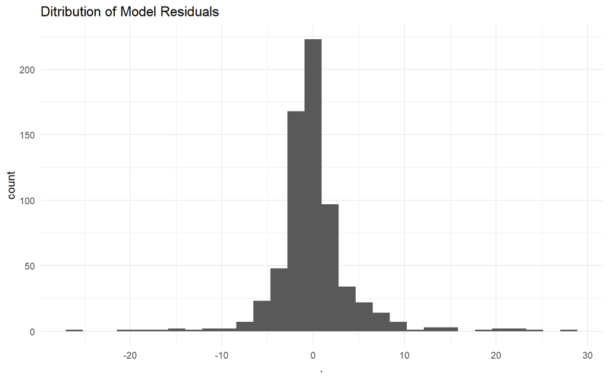

```r
ggplot(residuals(m1) %>%  as.data.frame(), aes(x = .))+
  geom_histogram()+
  ggtitle("Ditribution of Model Residuals")+
  theme_minimal()
```

#### 8.4.3.2 Gamma model

```r
m2 <- glmer(days ~
          subspecialty +
          insurance_type +
            age_category+
            District +
          central +
          gender +
          dow +
            ntransf +
          provider + (1|name),
               data = final4,
               family = Gamma(link=log),
               nAGQ = 1)

tab_model(m2)
```

|  | days |  |  |
| --- | --- | --- | --- |
| Predictors | Estimates | CI | p |
| (Intercept) | 14.85 | 5.75 – 38.39 | **<0.001** |
| subspecialty [Fem PM & RM] | 1.67 | 1.30 – 2.14 | **<0.001** |
| subspecialty [Mat-Fet Med] | 1.44 | 1.08 – 1.92 | **0.012** |
| subspecialty [Reprod End & Infert] | 2.08 | 1.55 – 2.78 | **<0.001** |
| insurance type [Medicaid] | 1.48 | 1.38 – 1.60 | **<0.001** |
| age category [40 to 49 years old] | 1.14 | 0.78 – 1.66 | 0.510 |
| age category [50 to 59 years old] | 1.14 | 0.78 – 1.67 | 0.495 |
| age category [60 years old or greater] | 1.16 | 0.78 – 1.73 | 0.469 |
| District [District II] | 0.89 | 0.58 – 1.38 | 0.608 |
| District [District III] | 0.88 | 0.58 – 1.33 | 0.539 |
| District [District IV] | 1.06 | 0.72 – 1.58 | 0.764 |
| District [District IX] | 0.78 | 0.50 – 1.22 | 0.269 |
| District [District V] | 0.85 | 0.54 – 1.36 | 0.504 |
| District [District VI] | 0.73 | 0.47 – 1.12 | 0.151 |
| District [District VII] | 0.99 | 0.63 – 1.55 | 0.966 |
| District [District VIII] | 0.96 | 0.62 – 1.49 | 0.865 |
| District [District XI] | 0.77 | 0.49 – 1.23 | 0.277 |
| District [District XII] | 0.93 | 0.53 – 1.62 | 0.791 |
| District [Missing] | 0.72 | 0.40 – 1.30 | 0.277 |
| central [No] | 1.05 | 0.93 – 1.17 | 0.443 |
| gender [Male] | 0.85 | 0.70 – 1.04 | 0.110 |
| dow [Tuesday] | 1.16 | 0.99 – 1.37 | 0.071 |
| dow [Wednesday] | 0.82 | 0.74 – 0.92 | **<0.001** |
| dow [Thursday] | 0.73 | 0.64 – 0.84 | **<0.001** |
| dow [Friday] | 0.78 | 0.67 – 0.92 | **0.002** |
| ntransf [No transfers] | 0.75 | 0.58 – 0.98 | **0.036** |
| ntransf [One transfer] | 0.97 | 0.74 – 1.26 | 0.808 |
| ntransf [Two transfers] | 0.93 | 0.70 – 1.23 | 0.590 |
| provider [MD] | 0.67 | 0.31 – 1.45 | 0.312 |
| Random Effects |  |  |  |
| σ<sup>2</sup> | 0.16 |  |  |
| τ<sub>00</sub> <sub>name</sub> | 0.48 |  |  |
| ICC | 0.75 |  |  |
| N <sub>name</sub> | 477 |  |  |
| Observations | 668 |  |  |
| Marginal R<sup>2</sup> / Conditional R<sup>2</sup> | 0.164 / 0.795 |  |  |

#### 8.4.3.3 Generalizing Estimating Equation

```r
m3 <- geeglm(days ~
          subspecialty +
          insurance_type +
            age_category +
            District +
          central +
          gender +
          dow +
            ntransf +
          provider,
          data = final4,
          id = NPI,
          std.err = "san.se",
          family = poisson(link = log),
          scale.fix = FALSE
          )

tab_model(m3)
```

|  | days |  |  |
| --- | --- | --- | --- |
| Predictors | Incidence Rate Ratios | CI | p |
| (Intercept) | 21.61 | 6.74 – 69.26 | **<0.001** |
| subspecialty [Fem PM & RM] | 1.57 | 1.29 – 1.91 | **<0.001** |
| subspecialty [Mat-Fet Med] | 1.15 | 0.91 – 1.45 | 0.251 |
| subspecialty [Reprod End & Infert] | 2.56 | 1.93 – 3.39 | **<0.001** |
| insurance type [Medicaid] | 1.51 | 1.31 – 1.74 | **<0.001** |
| age category [40 to 49 years old] | 1.30 | 0.98 – 1.73 | 0.065 |
| age category [50 to 59 years old] | 1.23 | 0.94 – 1.62 | 0.128 |
| age category [60 years old or greater] | 1.28 | 0.93 – 1.74 | 0.126 |
| District [District II] | 0.83 | 0.60 – 1.17 | 0.293 |
| District [District III] | 0.87 | 0.62 – 1.22 | 0.419 |
| District [District IV] | 1.08 | 0.78 – 1.51 | 0.641 |
| District [District IX] | 0.80 | 0.53 – 1.21 | 0.296 |
| District [District V] | 1.01 | 0.65 – 1.57 | 0.953 |
| District [District VI] | 0.81 | 0.55 – 1.20 | 0.296 |
| District [District VII] | 1.16 | 0.70 – 1.92 | 0.566 |
| District [District VIII] | 0.97 | 0.69 – 1.37 | 0.874 |
| District [District XI] | 0.78 | 0.54 – 1.12 | 0.180 |
| District [District XII] | 0.74 | 0.45 – 1.20 | 0.220 |
| District [Missing] | 0.70 | 0.49 – 1.02 | 0.062 |
| central [No] | 1.19 | 1.01 – 1.40 | **0.040** |
| gender [Male] | 0.86 | 0.70 – 1.05 | 0.140 |
| dow [Tuesday] | 1.07 | 0.81 – 1.42 | 0.630 |
| dow [Wednesday] | 0.87 | 0.72 – 1.05 | 0.155 |
| dow [Thursday] | 0.76 | 0.59 – 0.99 | **0.041** |
| dow [Friday] | 0.61 | 0.49 – 0.77 | **<0.001** |
| ntransf [No transfers] | 1.11 | 0.74 – 1.66 | 0.620 |
| ntransf [One transfer] | 0.94 | 0.63 – 1.41 | 0.763 |
| ntransf [Two transfers] | 1.10 | 0.68 – 1.81 | 0.692 |
| provider [MD] | 0.44 | 0.17 – 1.16 | 0.096 |
| N <sub>NPI</sub> | 477 |  |  |
| Observations | 668 |  |  |

### 8.4.4 Effects

We quickly look at some effect using the initial poisson mixed model.

#### 8.4.4.1 Insurance Type

Estimates with confidence interval of the number of days of waiting time.

```r
emmeans(lmmodel1, ~ insurance_type, type = "response",
        nuisance = c("District","central","gender",
                     "ntransf","provider"))
```

```
##  insurance_type    rate   SE  df asymp.LCL asymp.UCL
##  Blue Cross/Shield 15.0 2.14 Inf      11.4      19.9
##  Medicaid          21.6 3.14 Inf      16.3      28.7
##
## Results are averaged over the levels of: 5 nuisance factors, subspecialty, age_category, dow
## Confidence level used: 0.95
## Intervals are back-transformed from the log scale
```

```r
emmeans(lmmodel1, ~ subspecialty, type = "response",
        nuisance = c("District","central","gender",
                     "ntransf","provider"))
```

```
##  subspecialty        rate   SE  df asymp.LCL asymp.UCL
##  Gyn Onc             12.2 1.93 Inf      8.97      16.7
##  Fem PM & RM         20.0 3.08 Inf     14.81      27.1
##  Mat-Fet Med         16.6 2.49 Inf     12.33      22.2
##  Reprod End & Infert 26.0 4.26 Inf     18.88      35.9
##
## Results are averaged over the levels of: 5 nuisance factors, insurance_type, age_category, dow
## Confidence level used: 0.95
## Intervals are back-transformed from the log scale
```

```r
car::Anova(lmmodel1, type = 3)
```

```
## Analysis of Deviance Table (Type III Wald chisquare tests)
##
## Response: days
##                   Chisq Df Pr(>Chisq)
## (Intercept)     64.0727  1  1.199e-15 ***
## subspecialty    54.1579  3  1.038e-11 ***
## insurance_type 110.3162  1  < 2.2e-16 ***
## age_category     1.5345  3   0.674320
## District        10.8356 11   0.457137
## central          0.7531  1   0.385498
## gender           2.5738  1   0.108646
## dow             36.2851  4  2.528e-07 ***
## ntransf         11.4163  3   0.009675 **
## provider         2.7999  1   0.094273 .
## ---
## Signif. codes:  0 '***' 0.001 '**' 0.01 '*' 0.05 '.' 0.1 ' ' 1
```

We can show the effect in a graph. Notice that these are **model adjusted means**, that is, it is not just average waiting time, but the average waiting time controlled for the other variable in the model.

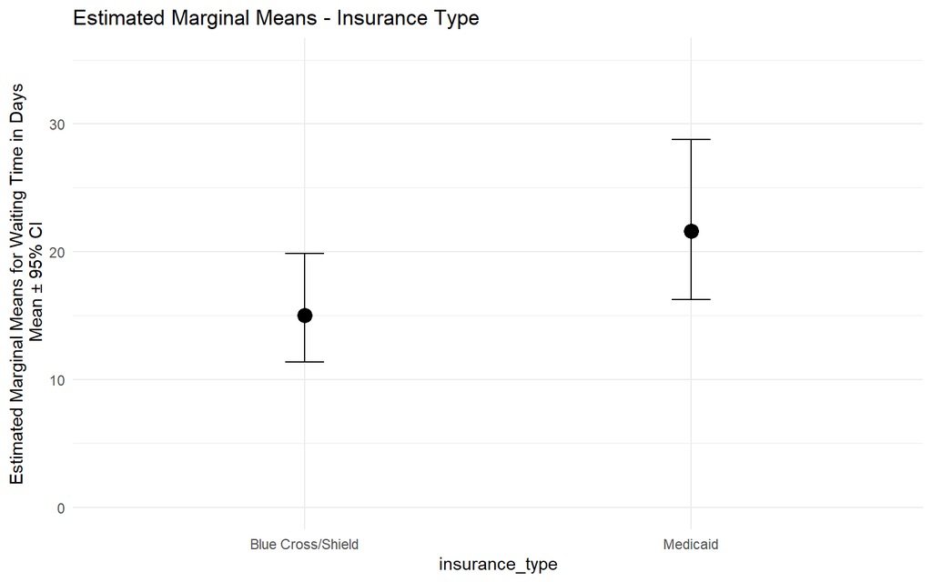

```r
edata <- emmeans(lmmodel1, ~ insurance_type, type = "response",
                 nuisance = c("District","central","gender",
                     "ntransf","provider")) %>%
  as.data.frame()

ggplot(edata, aes(x = insurance_type, y = rate))+
  geom_point(size = 2, stroke = 2)+
  geom_errorbar(aes(ymin = asymp.LCL, ymax = asymp.UCL), width = 0.1)+
  ylim(0,35)+
  ggtitle("Estimated Marginal Means - Insurance Type")+
  ylab("Estimated Marginal Means for Waiting Time in Days\n Mean ± 95% CI")+
  theme_minimal()
```

#### 8.4.4.2 Subspecialty

Subspecialty is significant as we see in the ANOVA table.

```r
car::Anova(lmmodel1, type = 3)
```

```
## Analysis of Deviance Table (Type III Wald chisquare tests)
##
## Response: days
##                   Chisq Df Pr(>Chisq)
## (Intercept)     64.0727  1  1.199e-15 ***
## subspecialty    54.1579  3  1.038e-11 ***
## insurance_type 110.3162  1  < 2.2e-16 ***
## age_category     1.5345  3   0.674320
## District        10.8356 11   0.457137
## central          0.7531  1   0.385498
## gender           2.5738  1   0.108646
## dow             36.2851  4  2.528e-07 ***
## ntransf         11.4163  3   0.009675 **
## provider         2.7999  1   0.094273 .
## ---
## Signif. codes:  0 '***' 0.001 '**' 0.01 '*' 0.05 '.' 0.1 ' ' 1
```

Estimates with confidence interval of the number of days of waiting time.

```r
emmeans(lmmodel1, pairwise~ subspecialty, type = "response", adjust = "bon",nuisance = c("District","central","gender",
                     "ntransf","provider"))
```

```
## $emmeans
##  subspecialty        rate   SE  df asymp.LCL asymp.UCL
##  Gyn Onc             12.2 1.93 Inf      8.97      16.7
##  Fem PM & RM         20.0 3.08 Inf     14.81      27.1
##  Mat-Fet Med         16.6 2.49 Inf     12.33      22.2
##  Reprod End & Infert 26.0 4.26 Inf     18.88      35.9
##
## Results are averaged over the levels of: 5 nuisance factors, insurance_type, age_category, dow
## Confidence level used: 0.95
## Intervals are back-transformed from the log scale
##
## $contrasts
##  contrast                            ratio     SE  df null z.ratio p.value
##  Gyn Onc / Fem PM & RM               0.611 0.0566 Inf    1  -5.320  <.0001
##  Gyn Onc / (Mat-Fet Med)             0.738 0.0786 Inf    1  -2.849  0.0263
##  Gyn Onc / Reprod End & Infert       0.470 0.0514 Inf    1  -6.907  <.0001
##  Fem PM & RM / (Mat-Fet Med)         1.209 0.1214 Inf    1   1.885  0.3564
##  Fem PM & RM / Reprod End & Infert   0.769 0.0803 Inf    1  -2.514  0.0717
##  (Mat-Fet Med) / Reprod End & Infert 0.637 0.0733 Inf    1  -3.920  0.0005
##
## Results are averaged over the levels of: 5 nuisance factors, insurance_type, age_category, dow
## P value adjustment: bonferroni method for 6 tests
## Tests are performed on the log scale
```

We can show the effect in a graph.

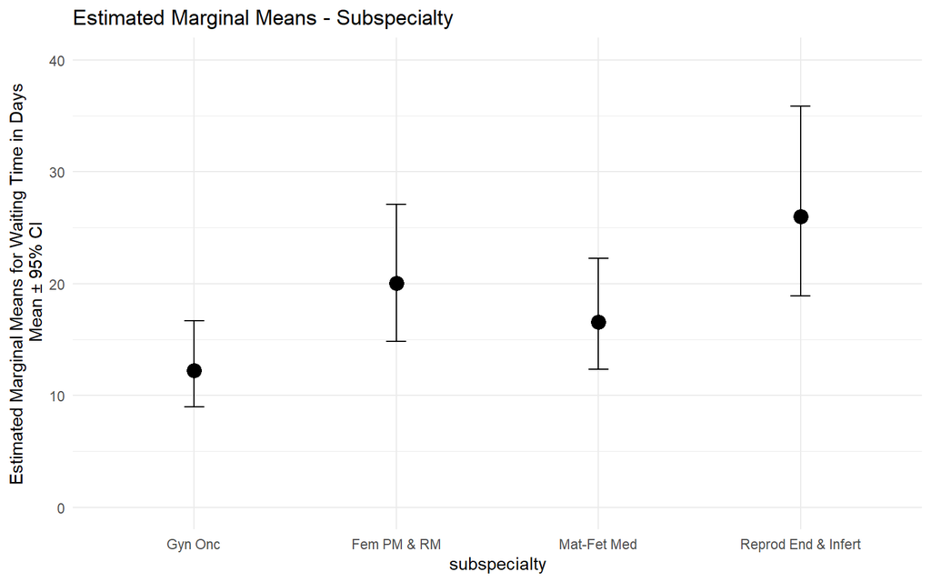

```r
edata <- emmeans(lmmodel1, ~ subspecialty, type = "response",
                 nuisance = c("District","central","gender",
                     "ntransf","provider")) %>%
  as.data.frame()

ggplot(edata, aes(x = subspecialty, y = rate))+
  geom_point(size = 2, stroke = 2)+
  geom_errorbar(aes(ymin = asymp.LCL, ymax = asymp.UCL), width = 0.1)+
  ylim(0,40)+
  ggtitle("Estimated Marginal Means - Subspecialty")+
  ylab("Estimated Marginal Means for Waiting Time in Days\n Mean ± 95% CI")+
  theme_minimal()
```

#### 8.4.4.3 Day of the Week

DOW is significant.

Estimates with confidence interval of the number of days of waiting time.

```r
car::Anova(lmmodel1, type = 3)
```

```
## Analysis of Deviance Table (Type III Wald chisquare tests)
##
## Response: days
##                   Chisq Df Pr(>Chisq)
## (Intercept)     64.0727  1  1.199e-15 ***
## subspecialty    54.1579  3  1.038e-11 ***
## insurance_type 110.3162  1  < 2.2e-16 ***
## age_category     1.5345  3   0.674320
## District        10.8356 11   0.457137
## central          0.7531  1   0.385498
## gender           2.5738  1   0.108646
## dow             36.2851  4  2.528e-07 ***
## ntransf         11.4163  3   0.009675 **
## provider         2.7999  1   0.094273 .
## ---
## Signif. codes:  0 '***' 0.001 '**' 0.01 '*' 0.05 '.' 0.1 ' ' 1
```

```r
emmeans(lmmodel1, ~ dow, type = "response",
        nuisance = c("District","central","gender",
                     "ntransf","provider"))
```

```
##  dow       rate   SE  df asymp.LCL asymp.UCL
##  Monday    20.7 3.09 Inf      15.4      27.7
##  Tuesday   21.7 3.32 Inf      16.1      29.3
##  Wednesday 16.9 2.43 Inf      12.8      22.4
##  Thursday  15.8 2.29 Inf      11.9      21.0
##  Friday    15.9 2.35 Inf      11.9      21.2
##
## Results are averaged over the levels of: 5 nuisance factors, subspecialty, insurance_type, age_category
## Confidence level used: 0.95
## Intervals are back-transformed from the log scale
```

We can show the effect in a graph.

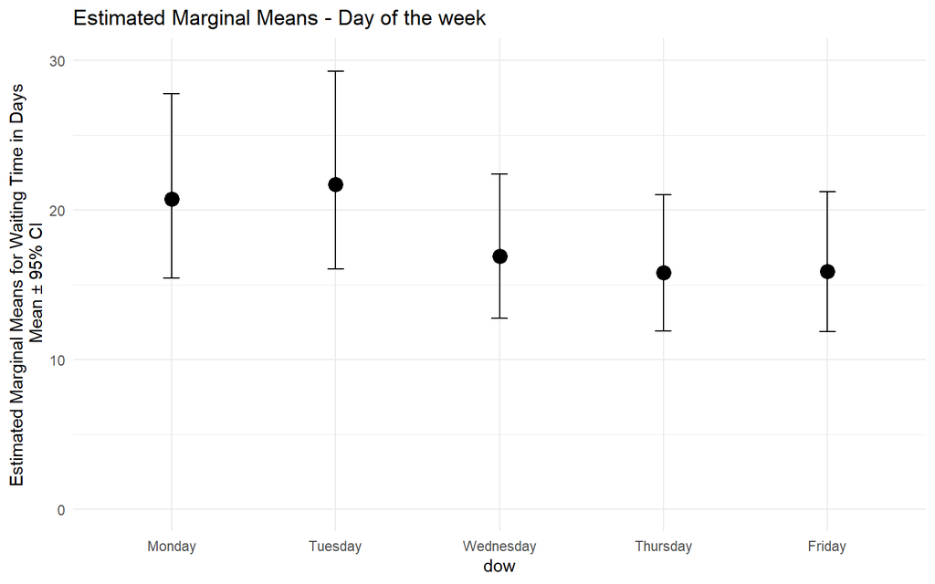

```r
edata <- emmeans(lmmodel1, ~ dow, type = "response",
                 nuisance = c("District","central","gender",
                     "ntransf","provider")) %>%
  as.data.frame()

ggplot(edata, aes(x = dow, y = rate))+
  geom_point(size = 2, stroke = 2)+
  geom_errorbar(aes(ymin = asymp.LCL, ymax = asymp.UCL), width = 0.1)+
  ylim(0,30)+
  ggtitle("Estimated Marginal Means - Day of the week")+
  ylab("Estimated Marginal Means for Waiting Time in Days\n Mean ± 95% CI")+
  theme_minimal()
```

#### 8.4.4.4 Gender

Gender is almost significant. So we take a look at its effect as well.

```r
car::Anova(lmmodel1, type = 3)
```

```
## Analysis of Deviance Table (Type III Wald chisquare tests)
##
## Response: days
##                   Chisq Df Pr(>Chisq)
## (Intercept)     64.0727  1  1.199e-15 ***
## subspecialty    54.1579  3  1.038e-11 ***
## insurance_type 110.3162  1  < 2.2e-16 ***
## age_category     1.5345  3   0.674320
## District        10.8356 11   0.457137
## central          0.7531  1   0.385498
## gender           2.5738  1   0.108646
## dow             36.2851  4  2.528e-07 ***
## ntransf         11.4163  3   0.009675 **
## provider         2.7999  1   0.094273 .
## ---
## Signif. codes:  0 '***' 0.001 '**' 0.01 '*' 0.05 '.' 0.1 ' ' 1
```

```r
emmeans(lmmodel1, ~ gender, type = "response",
        nuisance = c("District","central",
                     "ntransf","provider"))
```

```
##  gender rate   SE  df asymp.LCL asymp.UCL
##  Female 19.1 2.86 Inf      14.3      25.6
##  Male   17.0 2.47 Inf      12.8      22.6
##
## Results are averaged over the levels of: 4 nuisance factors, subspecialty, insurance_type, age_category, dow
## Confidence level used: 0.95
## Intervals are back-transformed from the log scale
```

We can show the effect in a graph.

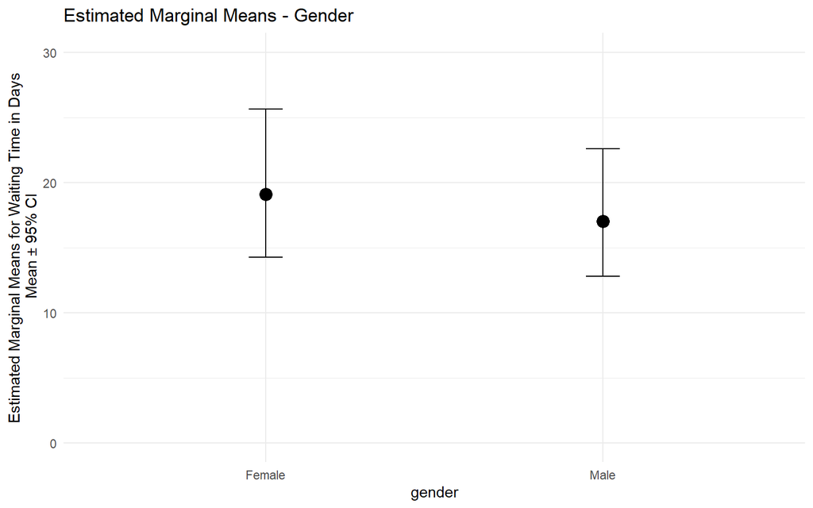

```r
edata <- emmeans(lmmodel1, ~ gender, type = "response",
                 nuisance = c("District","central",
                     "ntransf","provider")) %>%
  as.data.frame()

ggplot(edata, aes(x = gender, y =rate))+
  geom_point(size = 2, stroke = 2)+
  geom_errorbar(aes(ymin = asymp.LCL, ymax = asymp.UCL), width = 0.1)+
  ylim(0,30)+
  ggtitle("Estimated Marginal Means - Gender")+
  ylab("Estimated Marginal Means for Waiting Time in Days\n Mean ± 95% CI")+
  theme_minimal()
```

### 8.4.5 Moderation by Subspecialty

Does subspecialty affect the difference in waiting times between private and Medicaid? The ANOVA table below shows that yes, we have evidence for the interaction.

```r
final4$it <- relevel(final4$insurance_type, ref = "Medicaid")

lmmodel2 <-
  glmer(days ~
          subspecialty * it +
          age_category + District +
          central +
          gender +
          dow +
          ntransf +
          provider + (1|name),
               data = final4,
               family = poisson, #Count data
               nAGQ = 1)

tab_model(lmmodel2)
```

|  | days |  |  |
| --- | --- | --- | --- |
| Predictors | Incidence Rate Ratios | CI | p |
| (Intercept) | 24.27 | 12.07 – 48.80 | **<0.001** |
| subspecialty [Fem PM & RM] | 1.79 | 1.48 – 2.17 | **<0.001** |
| subspecialty [Mat-Fet Med] | 1.14 | 0.91 – 1.44 | 0.248 |
| subspecialty [Reprod End & Infert] | 2.13 | 1.68 – 2.70 | **<0.001** |
| it [Blue Cross/Shield] | 0.71 | 0.63 – 0.81 | **<0.001** |
| age category [40 to 49 years old] | 1.16 | 0.88 – 1.53 | 0.280 |
| age category [50 to 59 years old] | 1.19 | 0.90 – 1.56 | 0.223 |
| age category [60 years old or greater] | 1.19 | 0.89 – 1.58 | 0.251 |
| District [District II] | 0.87 | 0.64 – 1.18 | 0.377 |
| District [District III] | 0.91 | 0.68 – 1.23 | 0.549 |
| District [District IV] | 1.08 | 0.81 – 1.43 | 0.609 |
| District [District IX] | 0.82 | 0.59 – 1.12 | 0.212 |
| District [District V] | 0.92 | 0.66 – 1.27 | 0.609 |
| District [District VI] | 0.76 | 0.56 – 1.03 | 0.074 |
| District [District VII] | 0.99 | 0.72 – 1.37 | 0.949 |
| District [District VIII] | 0.94 | 0.69 – 1.28 | 0.688 |
| District [District XI] | 0.80 | 0.57 – 1.11 | 0.185 |
| District [District XII] | 0.92 | 0.61 – 1.39 | 0.700 |
| District [Missing] | 0.72 | 0.47 – 1.11 | 0.135 |
| central [No] | 1.03 | 0.93 – 1.15 | 0.532 |
| gender [Male] | 0.88 | 0.77 – 1.02 | 0.088 |
| dow [Tuesday] | 1.04 | 0.92 – 1.17 | 0.548 |
| dow [Wednesday] | 0.79 | 0.72 – 0.87 | **<0.001** |
| dow [Thursday] | 0.71 | 0.63 – 0.81 | **<0.001** |
| dow [Friday] | 0.72 | 0.62 – 0.84 | **<0.001** |
| ntransf [No transfers] | 0.83 | 0.64 – 1.09 | 0.176 |
| ntransf [One transfer] | 0.93 | 0.71 – 1.21 | 0.580 |
| ntransf [Two transfers] | 0.94 | 0.71 – 1.25 | 0.657 |
| provider [MD] | 0.64 | 0.38 – 1.09 | 0.102 |
| subspecialty [Fem PM & RM] * it [Blue Cross/Shield] | 0.83 | 0.72 – 0.97 | **0.016** |
| subspecialty [Mat-Fet Med] * it [Blue Cross/Shield] | 1.27 | 1.07 – 1.51 | **0.005** |
| subspecialty [Reprod End & Infert] * it [Blue Cross/Shield] | 1.02 | 0.85 – 1.23 | 0.807 |
| Random Effects |  |  |  |
| σ<sup>2</sup> | 0.07 |  |  |
| τ<sub>00</sub> <sub>name</sub> | 0.49 |  |  |
| ICC | 0.87 |  |  |
| N <sub>name</sub> | 477 |  |  |
| Observations | 668 |  |  |
| Marginal R<sup>2</sup> / Conditional R<sup>2</sup> | 0.169 / 0.891 |  |  |

```r
car::Anova(lmmodel2, type = 3)
```

```
## Analysis of Deviance Table (Type III Wald chisquare tests)
##
## Response: days
##                   Chisq Df Pr(>Chisq)
## (Intercept)     80.0406  1  < 2.2e-16 ***
## subspecialty    60.2330  3  5.242e-13 ***
## it              28.2772  1  1.051e-07 ***
## age_category     1.5878  3    0.66215
## District        10.5522 11    0.48150
## central          0.3899  1    0.53236
## gender           2.9094  1    0.08806 .
## dow             43.4571  4  8.317e-09 ***
## ntransf          5.7527  3    0.12428
## provider         2.6748  1    0.10195
## subspecialty:it 45.0764  3  8.913e-10 ***
## ---
## Signif. codes:  0 '***' 0.001 '**' 0.01 '*' 0.05 '.' 0.1 ' ' 1
```

We can graph the interaction to interpret it.

In general waiting time is longer for Medicaid, but mroe so in two subspecialties.

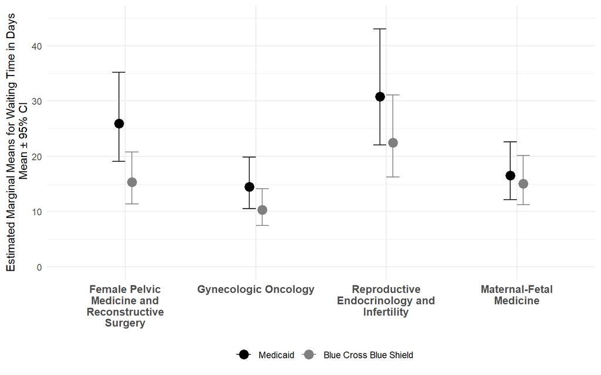

```r
edata <- emmeans(lmmodel2, ~ it | subspecialty,
                 type = "response",
                 nuisance = c("District","central","gender",
                     "ntransf","provider")) %>%
  as.data.frame()

edata$ss <- factor(edata$subspecialty,
                   levels = c("Fem PM & RM","Gyn Onc","Mat-Fet Med","Reprod End & Infert"),
                   labels = c("Female Pelvic Medicine and Reconstructive Surgery",
                              "Gynecologic Oncology",
                              "Maternal-Fetal Medicine",
                              "Reproductive Endocrinology and Infertility"))

edata$ss <- factor(edata$subspecialty,
                   levels = c("Fem PM & RM","Gyn Onc","Reprod End & Infert","Mat-Fet Med"),
                   labels = c("Female Pelvic Medicine and Reconstructive Surgery",
                              "Gynecologic Oncology",
                              "Reproductive Endocrinology and Infertility",
                              "Maternal-Fetal Medicine"))

edata$it <- factor(edata$it, labels = c("Medicaid","Blue Cross Blue Shield"))

library(stringr)
edata$ss2 <- factor(str_wrap(edata$ss, width = 20),
                    levels = c("Female Pelvic\nMedicine and\nReconstructive\nSurgery",
                               "Gynecologic Oncology",
                               "Reproductive\nEndocrinology and\nInfertility",
                               "Maternal-Fetal\nMedicine"))

ggplot(edata, aes(x = ss2, y = rate))+
  geom_point(aes(color = it), size = 2, stroke = 2,
                 position = position_dodge(width=0.2))+
  geom_errorbar(aes(ymin = asymp.LCL, ymax = asymp.UCL,
                    color = it), width = 0.2,
                position = position_dodge(width=0.2))+
  scale_color_manual(values = c("black","gray50"))+
  ylim(0,45)+
 # ggtitle("Estimated Marginal Means - Insurance Type")+
  ylab("Estimated Marginal Means for Waiting Time in Days\n Mean ± 95% CI")+
  theme_minimal()+
  theme(axis.title.x = element_blank(),
        axis.text.x = element_text(face = "bold",size = 10),
        legend.position = "bottom",
        legend.title = element_blank())
```

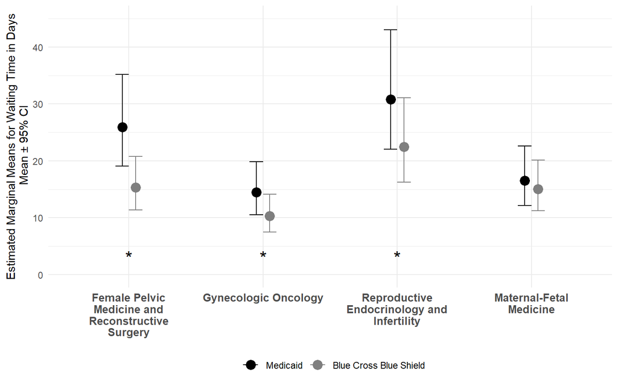

```r
ggsave("Figure 1b.tiff", height = 5, width = 8, dpi = 200)


ggplot(edata, aes(x = ss2, y = rate))+
  geom_point(aes(color = it), size = 2, stroke = 2,
                 position = position_dodge(width=0.2))+
  geom_errorbar(aes(ymin = asymp.LCL, ymax = asymp.UCL,
                    color = it), width = 0.2,
                position = position_dodge(width=0.2))+
  scale_color_manual(values = c("black","gray50"))+
  annotate(label = "*", x= c(1,2,3),y=3, geom = "text", size = 6)+
  ylim(0,45)+
 # ggtitle("Estimated Marginal Means - Insurance Type")+
  ylab("Estimated Marginal Means for Waiting Time in Days\n Mean ± 95% CI")+
  theme_minimal()+
  theme(axis.title.x = element_blank(),
        axis.text.x = element_text(face = "bold",size = 10),
        legend.position = "bottom",
        legend.title = element_blank())
```

```r
ggsave("Figure 1b with asterisk.tiff", height = 5, width = 8, dpi = 200)
```

Usually the graph above should be good enough, but people always want to conduct statistical tests.

```r
emmeans(lmmodel2, pairwise~ it | subspecialty,
                 type = "response",
        nuisance = c("District","central","gender",
                     "ntransf","provider")) %>% confint()
```

```
## $emmeans
## subspecialty = Gyn Onc:
##  it                rate   SE  df asymp.LCL asymp.UCL
##  Medicaid          14.5 2.33 Inf      10.6      19.8
##  Blue Cross/Shield 10.3 1.66 Inf       7.5      14.1
##
## subspecialty = Fem PM & RM:
##  it                rate   SE  df asymp.LCL asymp.UCL
##  Medicaid          25.9 4.05 Inf      19.1      35.2
##  Blue Cross/Shield 15.3 2.37 Inf      11.3      20.8
##
## subspecialty = Mat-Fet Med:
##  it                rate   SE  df asymp.LCL asymp.UCL
##  Medicaid          16.6 2.62 Inf      12.1      22.6
##  Blue Cross/Shield 15.0 2.24 Inf      11.2      20.1
##
## subspecialty = Reprod End & Infert:
##  it                rate   SE  df asymp.LCL asymp.UCL
##  Medicaid          30.8 5.25 Inf      22.1      43.0
##  Blue Cross/Shield 22.4 3.72 Inf      16.2      31.1
##
## Results are averaged over the levels of: 5 nuisance factors, age_category, dow
## Confidence level used: 0.95
## Intervals are back-transformed from the log scale
##
## $contrasts
## subspecialty = Gyn Onc:
##  contrast                       ratio     SE  df asymp.LCL asymp.UCL
##  Medicaid / (Blue Cross/Shield)  1.40 0.0898 Inf     1.239      1.59
##
## subspecialty = Fem PM & RM:
##  contrast                       ratio     SE  df asymp.LCL asymp.UCL
##  Medicaid / (Blue Cross/Shield)  1.69 0.0782 Inf     1.541      1.85
##
## subspecialty = Mat-Fet Med:
##  contrast                       ratio     SE  df asymp.LCL asymp.UCL
##  Medicaid / (Blue Cross/Shield)  1.10 0.0674 Inf     0.978      1.24
##
## subspecialty = Reprod End & Infert:
##  contrast                       ratio     SE  df asymp.LCL asymp.UCL
##  Medicaid / (Blue Cross/Shield)  1.37 0.1075 Inf     1.177      1.60
##
## Results are averaged over the levels of: 5 nuisance factors, age_category, dow
## Confidence level used: 0.95
## Intervals are back-transformed from the log scale
```

Here we provide p-values for the ratios within subspecialty.

```r
emmeans(lmmodel2, pairwise~ it | subspecialty,
                 type = "response",
        nuisance = c("District","central","gender",
                     "ntransf","provider"))$contrasts
```

```
## subspecialty = Gyn Onc:
##  contrast                       ratio     SE  df null z.ratio p.value
##  Medicaid / (Blue Cross/Shield)  1.40 0.0898 Inf    1   5.318  <.0001
##
## subspecialty = Fem PM & RM:
##  contrast                       ratio     SE  df null z.ratio p.value
##  Medicaid / (Blue Cross/Shield)  1.69 0.0782 Inf    1  11.297  <.0001
##
## subspecialty = Mat-Fet Med:
##  contrast                       ratio     SE  df null z.ratio p.value
##  Medicaid / (Blue Cross/Shield)  1.10 0.0674 Inf    1   1.599  0.1098
##
## subspecialty = Reprod End & Infert:
##  contrast                       ratio     SE  df null z.ratio p.value
##  Medicaid / (Blue Cross/Shield)  1.37 0.1075 Inf    1   4.044  0.0001
##
## Results are averaged over the levels of: 5 nuisance factors, age_category, dow
## Tests are performed on the log scale
```

### 8.4.6 Moderation by District

Adding to the model the interaction between District and Insurance Type. We keep the interaction between Subspecialty and Insurance Type because it was important (significant).

We see that the District by Insurance type interaction is significant.

```r
lmmodel3 <-
  glmer(days ~
          subspecialty * it +
          age_category + District* it +
          central +
          gender +
          dow +
          ntransf +
          provider + (1|name),
               data = final4,
               family = poisson, #Count data
               nAGQ = 1)

tab_model(lmmodel3)
```

|  | days |  |  |
| --- | --- | --- | --- |
| Predictors | Incidence Rate Ratios | CI | p |
| (Intercept) | 27.10 | 13.43 – 54.67 | **<0.001** |
| subspecialty [Fem PM & RM] | 1.78 | 1.46 – 2.16 | **<0.001** |
| subspecialty [Mat-Fet Med] | 1.12 | 0.89 – 1.41 | 0.347 |
| subspecialty [Reprod End & Infert] | 2.11 | 1.66 – 2.68 | **<0.001** |
| it [Blue Cross/Shield] | 0.61 | 0.51 – 0.72 | **<0.001** |
| age category [40 to 49 years old] | 1.14 | 0.87 – 1.50 | 0.337 |
| age category [50 to 59 years old] | 1.16 | 0.88 – 1.53 | 0.279 |
| age category [60 years old or greater] | 1.16 | 0.87 – 1.55 | 0.313 |
| District [District II] | 0.80 | 0.57 – 1.11 | 0.181 |
| District [District III] | 0.80 | 0.59 – 1.09 | 0.160 |
| District [District IV] | 0.94 | 0.70 – 1.27 | 0.696 |
| District [District IX] | 0.82 | 0.58 – 1.15 | 0.244 |
| District [District V] | 0.83 | 0.59 – 1.17 | 0.283 |
| District [District VI] | 0.74 | 0.54 – 1.02 | 0.063 |
| District [District VII] | 0.89 | 0.63 – 1.27 | 0.533 |
| District [District VIII] | 0.92 | 0.67 – 1.28 | 0.626 |
| District [District XI] | 0.71 | 0.49 – 1.04 | 0.076 |
| District [District XII] | 0.97 | 0.63 – 1.51 | 0.905 |
| District [Missing] | 0.88 | 0.55 – 1.40 | 0.582 |
| central [No] | 1.00 | 0.90 – 1.12 | 0.930 |
| gender [Male] | 0.88 | 0.77 – 1.02 | 0.087 |
| dow [Tuesday] | 1.00 | 0.88 – 1.13 | 0.993 |
| dow [Wednesday] | 0.77 | 0.70 – 0.86 | **<0.001** |
| dow [Thursday] | 0.71 | 0.63 – 0.81 | **<0.001** |
| dow [Friday] | 0.68 | 0.58 – 0.79 | **<0.001** |
| ntransf [No transfers] | 0.84 | 0.64 – 1.10 | 0.205 |
| ntransf [One transfer] | 0.93 | 0.72 – 1.22 | 0.622 |
| ntransf [Two transfers] | 0.98 | 0.73 – 1.30 | 0.877 |
| provider [MD] | 0.65 | 0.38 – 1.10 | 0.108 |
| subspecialty [Fem PM & RM] * it [Blue Cross/Shield] | 0.85 | 0.73 – 1.00 | **0.043** |
| subspecialty [Mat-Fet Med] * it [Blue Cross/Shield] | 1.35 | 1.14 – 1.61 | **0.001** |
| subspecialty [Reprod End & Infert] * it [Blue Cross/Shield] | 1.04 | 0.85 – 1.26 | 0.715 |
| it [Blue Cross/Shield] * District [District II] | 1.19 | 0.96 – 1.47 | 0.107 |
| it [Blue Cross/Shield] * District [District III] | 1.30 | 1.09 – 1.56 | **0.004** |
| it [Blue Cross/Shield] * District [District IV] | 1.28 | 1.06 – 1.56 | **0.012** |
| it [Blue Cross/Shield] * District [District IX] | 1.02 | 0.82 – 1.28 | 0.855 |
| it [Blue Cross/Shield] * District [District V] | 1.26 | 1.02 – 1.56 | **0.033** |
| it [Blue Cross/Shield] * District [District VI] | 1.04 | 0.85 – 1.26 | 0.702 |
| it [Blue Cross/Shield] * District [District VII] | 1.22 | 0.95 – 1.57 | 0.120 |
| it [Blue Cross/Shield] * District [District VIII] | 1.06 | 0.86 – 1.30 | 0.612 |
| it [Blue Cross/Shield] * District [District XI] | 1.24 | 0.96 – 1.59 | 0.098 |
| it [Blue Cross/Shield] * District [District XII] | 0.96 | 0.72 – 1.28 | 0.778 |
| it [Blue Cross/Shield] * District [Missing] | 0.75 | 0.55 – 1.03 | 0.080 |
| Random Effects |  |  |  |
| σ<sup>2</sup> | 0.07 |  |  |
| τ<sub>00</sub> <sub>name</sub> | 0.49 |  |  |
| ICC | 0.87 |  |  |
| N <sub>name</sub> | 477 |  |  |
| Observations | 668 |  |  |
| Marginal R<sup>2</sup> / Conditional R<sup>2</sup> | 0.177 / 0.892 |  |  |

```r
car::Anova(lmmodel3, type = 3)
```

```
## Analysis of Deviance Table (Type III Wald chisquare tests)
##
## Response: days
##                   Chisq Df Pr(>Chisq)
## (Intercept)     84.8720  1  < 2.2e-16 ***
## subspecialty    59.6310  3  7.048e-13 ***
## it              31.4610  1  2.035e-08 ***
## age_category     1.2432  3   0.742657
## District         7.5478 11   0.753144
## central          0.0076  1   0.930452
## gender           2.9232  1   0.087316 .
## dow             40.4022  4  3.574e-08 ***
## ntransf          5.8134  3   0.121051
## provider         2.5859  1   0.107822
## subspecialty:it 47.8463  3  2.296e-10 ***
## it:District     25.5438 11   0.007583 **
## ---
## Signif. codes:  0 '***' 0.001 '**' 0.01 '*' 0.05 '.' 0.1 ' ' 1
```

We can graph the interaction to interpret it.

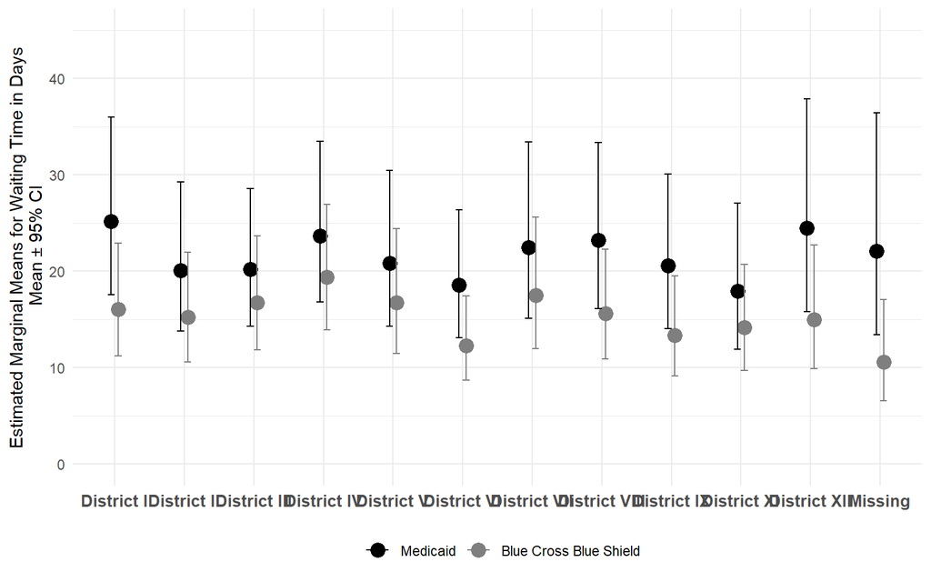

```r
edata <- emmeans(lmmodel3, ~ it | District,
                 nuisance = c("dow","provider","ntransf",
                              "central","gender"),
                 type = "response") %>%
  as.data.frame()

edata$dt <- factor(edata$District, levels = c("District I",
                                              "District II",
                                              "District III",
                                              "District IV",
                                              "District V",
                                              "District VI",
                                              "District VII",
                                              "District VIII",
                                              "District IX",
                                              "District XI",
                                              "District XII",
                                              "Missing"))

edata$it <- factor(edata$it, labels = c("Medicaid","Blue Cross Blue Shield"))

ggplot(edata, aes(x = dt, y = rate))+
  geom_point(aes(color = it), size = 2, stroke = 2,
                 position = position_dodge(width=0.2))+
  geom_errorbar(aes(ymin = asymp.LCL, ymax = asymp.UCL,
                    color = it), width = 0.2,
                position = position_dodge(width=0.2))+
  scale_color_manual(values = c("black","gray50"))+
  ylim(0,45)+
 # ggtitle("Estimated Marginal Means - Insurance Type")+
  ylab("Estimated Marginal Means for Waiting Time in Days\n Mean ± 95% CI")+
  theme_minimal()+
  theme(axis.title.x = element_blank(),
        axis.text.x = element_text(face = "bold",size = 10),
        legend.position = "bottom",
        legend.title = element_blank())
```

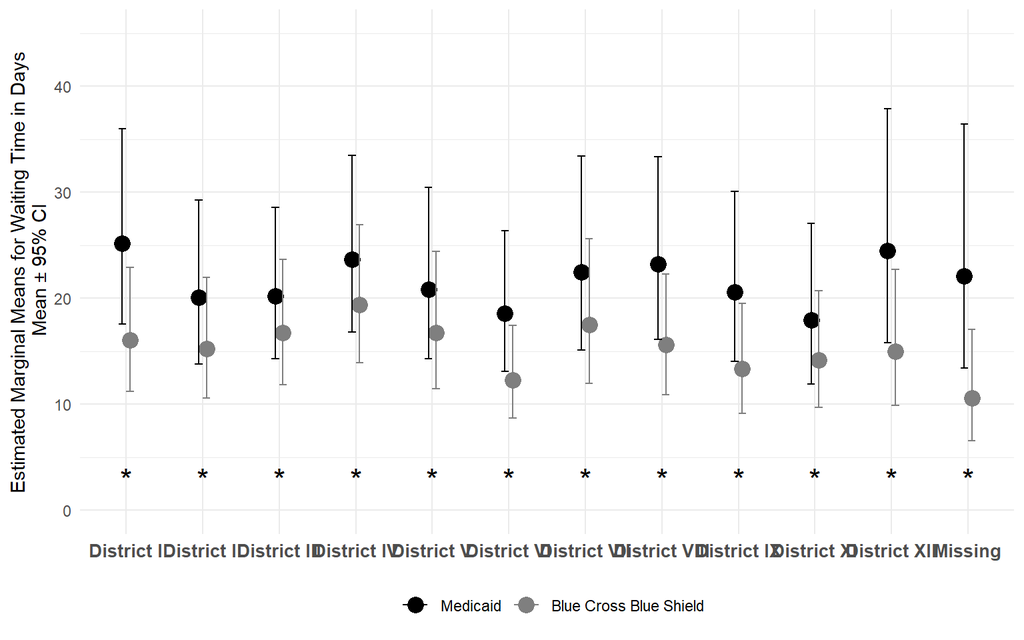

```r
ggsave("Figure District.tiff", height = 5, width = 10, dpi = 200)


ggplot(edata, aes(x = dt, y = rate))+
  geom_point(aes(color = it), size = 2, stroke = 2,
                 position = position_dodge(width=0.2))+
  geom_errorbar(aes(ymin = asymp.LCL, ymax = asymp.UCL,
                    color = it), width = 0.2,
                position = position_dodge(width=0.2))+
  scale_color_manual(values = c("black","gray50"))+
  annotate(label = "*", x= c(1:12),y=3, geom = "text", size = 6)+
  ylim(0,45)+
 # ggtitle("Estimated Marginal Means - Insurance Type")+
  ylab("Estimated Marginal Means for Waiting Time in Days\n Mean ± 95% CI")+
  theme_minimal()+
  theme(axis.title.x = element_blank(),
        axis.text.x = element_text(face = "bold",size = 10),
        legend.position = "bottom",
        legend.title = element_blank())
```

```r
ggsave("Figure District with asterisk.tiff", height = 5, width = 10, dpi = 200)
```

Here we have the size of the difference in each District. The fact that the interaction is significant means that we have evidence that the difference betweeen Insurance Types is not the same in all districts.

```r
emmeans(lmmodel3, pairwise~ it | District,
        nuisance = c("dow","provider","ntransf",
                              "central","gender"),
        type = "response") %>% confint()
```

```
## $emmeans
## District = District I:
##  it                rate   SE  df asymp.LCL asymp.UCL
##  Medicaid          25.2 4.61 Inf     17.58      36.0
##  Blue Cross/Shield 16.0 2.91 Inf     11.23      22.9
##
## District = District II:
##  it                rate   SE  df asymp.LCL asymp.UCL
##  Medicaid          20.1 3.86 Inf     13.81      29.3
##  Blue Cross/Shield 15.2 2.84 Inf     10.56      22.0
##
## District = District III:
##  it                rate   SE  df asymp.LCL asymp.UCL
##  Medicaid          20.2 3.57 Inf     14.28      28.6
##  Blue Cross/Shield 16.8 2.95 Inf     11.88      23.7
##
## District = District IV:
##  it                rate   SE  df asymp.LCL asymp.UCL
##  Medicaid          23.7 4.17 Inf     16.79      33.5
##  Blue Cross/Shield 19.4 3.26 Inf     13.93      26.9
##
## District = District IX:
##  it                rate   SE  df asymp.LCL asymp.UCL
##  Medicaid          20.6 3.99 Inf     14.06      30.1
##  Blue Cross/Shield 13.4 2.58 Inf      9.17      19.5
##
## District = District V:
##  it                rate   SE  df asymp.LCL asymp.UCL
##  Medicaid          20.9 4.04 Inf     14.29      30.5
##  Blue Cross/Shield 16.8 3.23 Inf     11.49      24.5
##
## District = District VI:
##  it                rate   SE  df asymp.LCL asymp.UCL
##  Medicaid          18.6 3.32 Inf     13.12      26.4
##  Blue Cross/Shield 12.3 2.19 Inf      8.70      17.5
##
## District = District VII:
##  it                rate   SE  df asymp.LCL asymp.UCL
##  Medicaid          22.5 4.54 Inf     15.14      33.4
##  Blue Cross/Shield 17.5 3.40 Inf     11.95      25.6
```

[output cut: 62 more lines]

```
## District = District XI:
##  contrast                       ratio     SE  df asymp.LCL asymp.UCL
##  Medicaid / (Blue Cross/Shield)  1.27 0.1445 Inf      1.01      1.58
##
## District = District XII:
##  contrast                       ratio     SE  df asymp.LCL asymp.UCL
##  Medicaid / (Blue Cross/Shield)  1.64 0.2170 Inf      1.26      2.12
##
## District = Missing:
##  contrast                       ratio     SE  df asymp.LCL asymp.UCL
##  Medicaid / (Blue Cross/Shield)  2.08 0.3191 Inf      1.54      2.81
##
## Results are averaged over the levels of: 5 nuisance factors, subspecialty, age_category
## Confidence level used: 0.95
## Intervals are back-transformed from the log scale
```

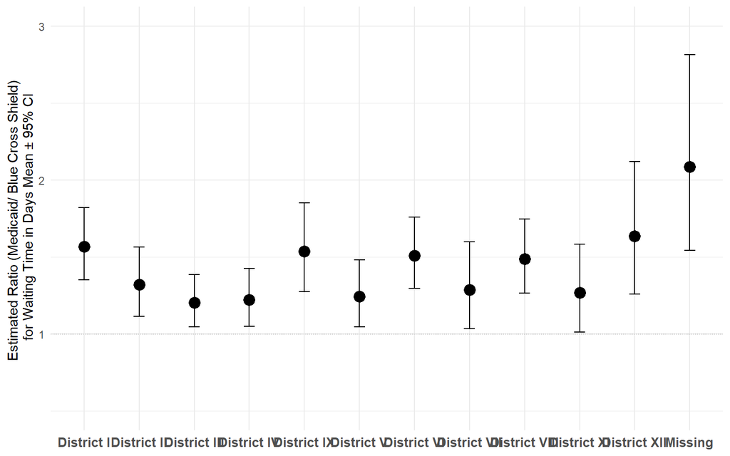

```r
fdata <- emmeans(lmmodel3, pairwise~ it | District,
        nuisance = c("dow","provider","ntransf",
                              "central","gender"),
        type = "response") %>% confint() %>%
  as.data.frame()

ggplot(fdata[1:12,], aes(x = contrasts.District, y = contrasts.ratio))+
  geom_point(size = 2, stroke = 2)+
  geom_errorbar(aes(ymin = contrasts.asymp.LCL, ymax = contrasts.asymp.UCL
                    ), width = 0.2)+
  geom_hline(yintercept = 1, color = "gray50", size = 0.1, linetype = "dotted")+
  ylim(0.5,3)+
 # ggtitle("Estimated Marginal Means - Insurance Type")+
  ylab("Estimated Ratio (Medicaid/ Blue Cross Shield) \n for Waiting Time in Days Mean ± 95% CI")+
  theme_minimal()+
  theme(axis.title.x = element_blank(),
        axis.text.x = element_text(face = "bold",size = 10),
        legend.position = "bottom",
        legend.title = element_blank())
```

```r
ggsave("Figure District Differences.tiff", height = 5, width = 10, dpi = 200)
```

```r
emmeans(lmmodel3, pairwise~ it | District,
        nuisance = c("dow","provider","ntransf",
                              "central","gender"),
        type = "response")$contrasts
```

```
## District = District I:
##  contrast                       ratio     SE  df null z.ratio p.value
##  Medicaid / (Blue Cross/Shield)  1.57 0.1192 Inf    1   5.930  <.0001
##
## District = District II:
##  contrast                       ratio     SE  df null z.ratio p.value
##  Medicaid / (Blue Cross/Shield)  1.32 0.1141 Inf    1   3.216  0.0013
##
## District = District III:
##  contrast                       ratio     SE  df null z.ratio p.value
##  Medicaid / (Blue Cross/Shield)  1.20 0.0860 Inf    1   2.594  0.0095
##
## District = District IV:
##  contrast                       ratio     SE  df null z.ratio p.value
##  Medicaid / (Blue Cross/Shield)  1.22 0.0955 Inf    1   2.582  0.0098
##
## District = District IX:
##  contrast                       ratio     SE  df null z.ratio p.value
##  Medicaid / (Blue Cross/Shield)  1.54 0.1459 Inf    1   4.524  <.0001
##
## District = District V:
##  contrast                       ratio     SE  df null z.ratio p.value
##  Medicaid / (Blue Cross/Shield)  1.25 0.1102 Inf    1   2.477  0.0132
##
## District = District VI:
##  contrast                       ratio     SE  df null z.ratio p.value
##  Medicaid / (Blue Cross/Shield)  1.51 0.1175 Inf    1   5.301  <.0001
##
## District = District VII:
##  contrast                       ratio     SE  df null z.ratio p.value
##  Medicaid / (Blue Cross/Shield)  1.29 0.1428 Inf    1   2.266  0.0235
##
## District = District VIII:
##  contrast                       ratio     SE  df null z.ratio p.value
##  Medicaid / (Blue Cross/Shield)  1.49 0.1220 Inf    1   4.831  <.0001
##
## District = District XI:
##  contrast                       ratio     SE  df null z.ratio p.value
##  Medicaid / (Blue Cross/Shield)  1.27 0.1445 Inf    1   2.078  0.0377
##
## District = District XII:
##  contrast                       ratio     SE  df null z.ratio p.value
##  Medicaid / (Blue Cross/Shield)  1.64 0.2170 Inf    1   3.705  0.0002
##
## District = Missing:
##  contrast                       ratio     SE  df null z.ratio p.value
##  Medicaid / (Blue Cross/Shield)  2.08 0.3191 Inf    1   4.798  <.0001
##
## Results are averaged over the levels of: 5 nuisance factors, subspecialty, age_category
## Tests are performed on the log scale
```

# 9 Model Both Insurances

## 9.1 Graphs

Here we try to visualize the waiting time for each insurance type, linking the providers by a line. We see that lines hardly go down from the private insurance to Medicaid (Medicaid times are hardly shorter).

**Note**- There are providers who accept Medicaid and Private, but dont have waiting time for both insurance types and as such they appear as isolated points in the graph.

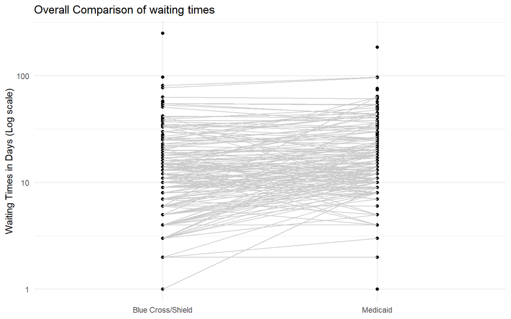

```r
final5 <- filter(final4, No_Medicaid == "Yes Medicaid",
                 nodata == "In the Analysis")

ggplot(final5, aes(x = insurance_type, y = days))+
  geom_point()+
  geom_line(aes(group = NPI), color = "gray80")+
  ggtitle("Overall Comparison of waiting times")+
  ylab("Waiting Times in Days (Log scale)")+
  scale_y_log10()+
  theme_minimal()+
  theme(
    axis.title.x = element_blank()
  )
```

Here we have a graph that only includes providers with data for both insurances, but notice that this is not the set of providers being analyzed, as 176 providers have data for only one insurance and are in the analysis but removed from this graph.

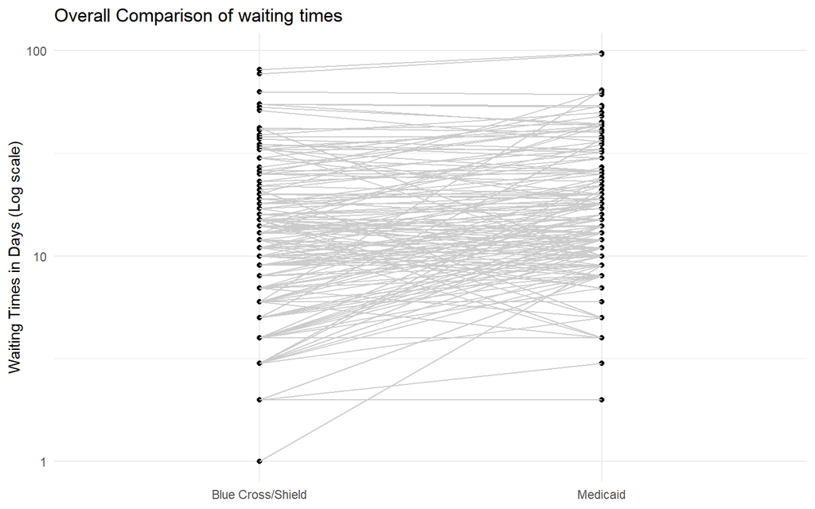

```r
final5b <- filter(final5, !is.na(days)) %>%
  left_join(final5 %>%
              filter(!is.na(days)) %>%
              group_by(NPI) %>%
              summarise(Ndata = n()) %>%
              ungroup()) %>%
  filter(Ndata == 2)


ggplot(final5b, aes(x = insurance_type, y = days))+
  geom_point()+
  geom_line(aes(group = NPI), color = "gray80")+
  ggtitle("Overall Comparison of waiting times")+
  ylab("Waiting Times in Days (Log scale)")+
  scale_y_log10()+
  theme_minimal()+
  theme(
    axis.title.x = element_blank()
  )
```

The results here are similar to previous, with more points above the line where Madicaid time is longer than Private time.

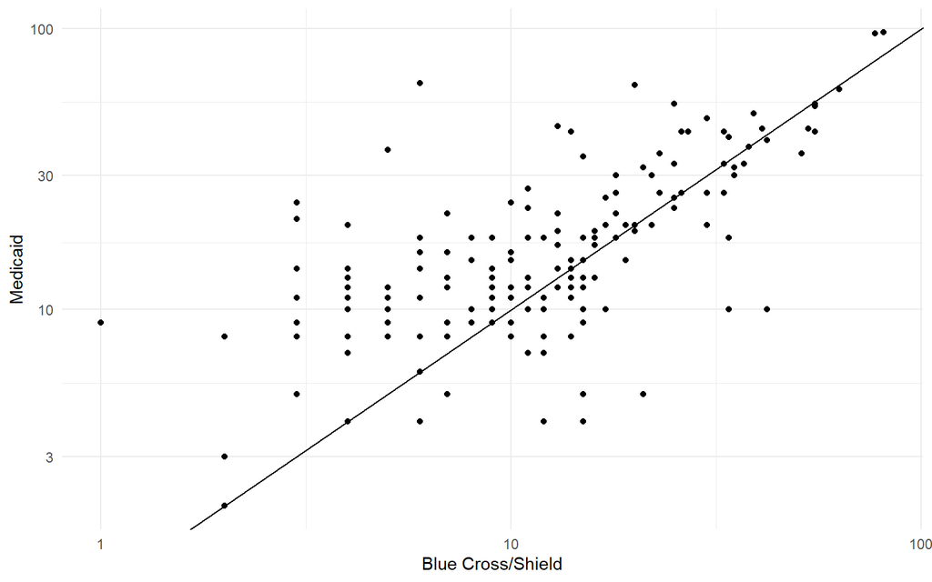

```r
temp <- tidyr::spread(final5 %>%
                        select(NPI,insurance_type,days),
                      key = insurance_type, value = days) %>%
  filter(!is.na(Medicaid), !is.na(`Blue Cross/Shield`))

ggplot(temp, aes(x = `Blue Cross/Shield`, y = Medicaid))+
  geom_point()+
  geom_abline()+
  scale_x_log10()+
  scale_y_log10()+
  theme_minimal()
```

## 9.2 Comparison Insurance Type

A few variables vary within Provider, across Insurance Types. It might be important to be aware of differences in these variables.

### 9.2.1 Day of the Week

The usual McNemar test is conducted when there are only two categories, and a generalizaiton of it, the McNemar–Bowker chi-square tests is used for more than two categories.

Day of the Week is highly signfiicant, which means that there is evidence of change in the distribution of Day of the Week when we move from one insurance type to the other.

```r
library(rcompanion)

x <- final5$dow[final5$insurance_type == "Medicaid"]
y <- final5$dow[final5$insurance_type == "Blue Cross/Shield"]

mcnemar.test(x,y)
```

```
##
##  McNemar's Chi-squared test
##
## data:  x and y
## McNemar's chi-squared = 153.97, df = 10, p-value < 2.2e-16
```

```r
#t1 <- table(x,y)

#nominalSymmetryTest(t1, exact = FALSE)
```

### 9.2.2 Central Number

Very little difference.

```r
x <- final5$central[final5$insurance_type == "Medicaid"]
y <- final5$central[final5$insurance_type == "Blue Cross/Shield"]

mcnemar.test(x,y)
```

```
##
##  McNemar's Chi-squared test with continuity correction
##
## data:  x and y
## McNemar's chi-squared = 3.1605, df = 1, p-value = 0.07544
```

### 9.2.3 Number of Transfer

Significant difference.

```r
x <- final5$ntransf[final5$insurance_type == "Medicaid"]
y <- final5$ntransf[final5$insurance_type == "Blue Cross/Shield"]

mcnemar.test(x,y)
```

```
##
##  McNemar's Chi-squared test
##
## data:  x and y
## McNemar's chi-squared = 17.004, df = 6, p-value = 0.009269
```

### 9.2.4 Reason for Exclusion

This is a big and sparse table and the test does not work for it, because of zeros and small sample sizes in many cells. We isntead create dummy variables for some categories with larger sample size and test them as binary variables.

```r
x <- (final5$reason == "Able to contact")[final5$insurance_type == "Medicaid"]
y <- (final5$reason == "Able to contact")[final5$insurance_type == "Blue Cross/Shield"]
mt <- mcnemar.test(x,y)
print(paste0("Reason = Able to Contact: p-value McNemar Test = ",mt$p.value))
```

```
## [1] "Reason = Able to Contact: p-value McNemar Test = 0.938864989823775"
```

```r
x <- (final5$reason == "Closed medical system (e.g. Kaiser or military hospital)")[final5$insurance_type == "Medicaid"]
y <- (final5$reason == "Closed medical system (e.g. Kaiser or military hospital)")[final5$insurance_type == "Blue Cross/Shield"]
mt <- mcnemar.test(x,y)
print(paste0("Reason = Closed medical system (e.g. Kaiser or military hospital): p-value McNemar Test = ",mt$p.value))
```

```
## [1] "Reason = Closed medical system (e.g. Kaiser or military hospital): p-value McNemar Test = 1"
```

```r
x <- (final5$reason == "Greater than 5 minutes on hold")[final5$insurance_type == "Medicaid"]
y <- (final5$reason == "Greater than 5 minutes on hold")[final5$insurance_type == "Blue Cross/Shield"]
mt <- mcnemar.test(x,y)
print(paste0("Reason = Greater than 5 minutes on hold: p-value McNemar Test = ",mt$p.value))
```

```
## [1] "Reason = Greater than 5 minutes on hold: p-value McNemar Test = 0.863831742854727"
```

```r
x <- (final5$reason == "Able to contact")[final5$insurance_type == "Medicaid"]
y <- (final5$reason == "Able to contact")[final5$insurance_type == "Blue Cross/Shield"]
mt <- mcnemar.test(x,y)
print(paste0("Reason = Able to Contact: p-value McNemar Test = ",mt$p.value))
```

```
## [1] "Reason = Able to Contact: p-value McNemar Test = 0.938864989823775"
```

```r
x <- (final5$reason == "Not accepting new patients")[final5$insurance_type == "Medicaid"]
y <- (final5$reason == "Not accepting new patients")[final5$insurance_type == "Blue Cross/Shield"]
mt <- mcnemar.test(x,y)
print(paste0("Reason = Not accepting new patients: p-value McNemar Test = ",mt$p.value))
```

```
## [1] "Reason = Not accepting new patients: p-value McNemar Test = 1"
```

```r
x <- (final5$reason == "Number contacted did not correspond to expected office/specialty")[final5$insurance_type == "Medicaid"]
y <- (final5$reason == "Number contacted did not correspond to expected office/specialty")[final5$insurance_type == "Blue Cross/Shield"]
mt <- mcnemar.test(x,y)
print(paste0("Reason = Number contacted did not correspond to expected office/specialty: p-value McNemar Test = ",mt$p.value))
```

```
## [1] "Reason = Number contacted did not correspond to expected office/specialty: p-value McNemar Test = 1"
```

```r
x <- (final5$reason == "Phone not answered or busy signal on repeat calls")[final5$insurance_type == "Medicaid"]
y <- (final5$reason == "Phone not answered or busy signal on repeat calls")[final5$insurance_type == "Blue Cross/Shield"]
mt <- mcnemar.test(x,y)
print(paste0("Reason = Phone not answered or busy signal on repeat calls: p-value McNemar Test = ",mt$p.value))
```

```
## [1] "Reason = Phone not answered or busy signal on repeat calls: p-value McNemar Test = 0.117524868096639"
```

```r
x <- (final5$reason == "Physician's personal phone")[final5$insurance_type == "Medicaid"]
y <- (final5$reason == "Physician's personal phone")[final5$insurance_type == "Blue Cross/Shield"]
mt <- mcnemar.test(x,y)
print(paste0("Reason = Physician's personal phone: p-value McNemar Test = ",mt$p.value))
```

```
## [1] "Reason = Physician's personal phone: p-value McNemar Test = 1"
```

```r
x <- (final5$reason == "Physician referral required before scheduling appointment")[final5$insurance_type == "Medicaid"]
y <- (final5$reason == "Physician referral required before scheduling appointment")[final5$insurance_type == "Blue Cross/Shield"]
mt <- mcnemar.test(x,y)
print(paste0("Reason = Physician referral required before scheduling appointment: p-value McNemar Test = ",mt$p.value))
```

```
## [1] "Reason = Physician referral required before scheduling appointment: p-value McNemar Test = 0.161429462367083"
```

```r
x <- (final5$reason == "Went to voicemail")[final5$insurance_type == "Medicaid"]
y <- (final5$reason == "Went to voicemail")[final5$insurance_type == "Blue Cross/Shield"]
mt <- mcnemar.test(x,y)
print(paste0("Reason = AWent to voicemail: p-value McNemar Test = ",mt$p.value))
```

```
## [1] "Reason = AWent to voicemail: p-value McNemar Test = 0.589638551626567"
```

## 9.3 Descriptives

A quick look on how different providers who accept Medicaid are from those who dont.

**NOTE** - Total and Insurance Type columns are only for providers who accept both insurance types.

```r
final5.half <- final5 %>% filter(insurance_type == "Medicaid")

temp <- final4 %>%
  left_join(final4 %>%
              group_by(NPI) %>%
              summarise(sumdays = sum(days, na.rm = T))) %>%
  filter(sumdays > 0)

temp.half <- filter(temp, insurance_type == "Medicaid")

table1( x = c(list(Total = final5.half),
              split(final5, final5$insurance_type),
              split(temp.half, temp.half$No_Medicaid )),
        labels = list(variables = list(gender = "Physician Gender",
                                       Age = "Physician Age in Years",
                                       subspecialty = "Subspecialty",
                                       provider = "Provider Credential Text",
                                       title = "Professional Title",
                                       grad = "Graduation Year",
                                       central = "Central Number",
                                       ntransf = "Number of Transfers",
                                       dow = "Day of the Week",
                                       reason = "Reason for Exclusions",
                                       days = "Business Days until Appointment",
                                       No_Medicaid = "MEDICAID Acceptance",
                                       District = "District",
                                       state = "State",
                                       Rural_Urban = "Rural or Urban"                                                                  ),
                      groups = list("","Insurance Type","MEDICAID Acceptance")),
        groupspan = c(1,2,2) )
```

|  | Total (N=354) | Insurance Type Blue Cross/Shield (N=354) | Insurance Type Medicaid (N=354) | MEDICAID Acceptance Yes Medicaid (N=354) | MEDICAID Acceptance No Medicaid (N=123) |
| --- | --- | --- | --- | --- | --- |
| Physician Gender |  |  |  |  |  |
| Female | 172 (48.6%) | 172 (48.6%) | 172 (48.6%) | 172 (48.6%) | 45 (36.6%) |
| Male | 182 (51.4%) | 182 (51.4%) | 182 (51.4%) | 182 (51.4%) | 78 (63.4%) |
| Physician Age in Years |  |  |  |  |  |
| Mean (SD) | 52.9 (9.81) | 52.9 (9.81) | 52.9 (9.81) | 52.9 (9.81) | 53.9 (9.95) |
| Median [Min, Max] | 52.5 [31.0, 92.0] | 52.5 [31.0, 92.0] | 52.5 [31.0, 92.0] | 52.5 [31.0, 92.0] | 53.0 [34.0, 86.0] |
| Subspecialty |  |  |  |  |  |
| Gyn Onc | 104 (29.4%) | 104 (29.4%) | 104 (29.4%) | 104 (29.4%) | 22 (17.9%) |
| Fem PM & RM | 131 (37.0%) | 131 (37.0%) | 131 (37.0%) | 131 (37.0%) | 31 (25.2%) |
| Mat-Fet Med | 84 (23.7%) | 84 (23.7%) | 84 (23.7%) | 84 (23.7%) | 18 (14.6%) |
| Reprod End & Infert | 35 (9.9%) | 35 (9.9%) | 35 (9.9%) | 35 (9.9%) | 52 (42.3%) |
| Provider Credential Text |  |  |  |  |  |
| DO | 7 (2.0%) | 7 (2.0%) | 7 (2.0%) | 7 (2.0%) | 1 (0.8%) |
| MD | 347 (98.0%) | 347 (98.0%) | 347 (98.0%) | 347 (98.0%) | 122 (99.2%) |
| Professional Title |  |  |  |  |  |
| Academics | 142 (40.1%) | 142 (40.1%) | 142 (40.1%) | 142 (40.1%) | 35 (28.5%) |
| Not academics | 212 (59.9%) | 212 (59.9%) | 212 (59.9%) | 212 (59.9%) | 88 (71.5%) |
| Graduation Year |  |  |  |  |  |
| [1960,1986] | 54 (15.3%) | 54 (15.3%) | 54 (15.3%) | 54 (15.3%) | 15 (12.2%) |
| (1986,1993] | 63 (17.8%) | 63 (17.8%) | 63 (17.8%) | 63 (17.8%) | 14 (11.4%) |
| (1993,2000] | 70 (19.8%) | 70 (19.8%) | 70 (19.8%) | 70 (19.8%) | 18 (14.6%) |
| (2000,2005] | 59 (16.7%) | 59 (16.7%) | 59 (16.7%) | 59 (16.7%) | 16 (13.0%) |
| (2005,2012] | 50 (14.1%) | 50 (14.1%) | 50 (14.1%) | 50 (14.1%) | 4 (3.3%) |
| Missing | 58 (16.4%) | 58 (16.4%) | 58 (16.4%) | 58 (16.4%) | 56 (45.5%) |
| Central Number |  |  |  |  |  |
| Yes | 70 (19.8%) | 87 (24.6%) | 70 (19.8%) | 70 (19.8%) | 18 (14.6%) |
| No | 284 (80.2%) | 267 (75.4%) | 284 (80.2%) | 284 (80.2%) | 105 (85.4%) |
| Number of Transfers |  |  |  |  |  |
| More than two transfers | 9 (2.5%) | 10 (2.8%) | 9 (2.5%) | 9 (2.5%) | 4 (3.3%) |
| No transfers | 226 (63.8%) | 188 (53.1%) | 226 (63.8%) | 226 (63.8%) | 73 (59.3%) |

[output cut: 94 more lines]

Descriptive analysis at the successful call level. You can see how many successful call were completed in each subspecialty, and for each type.

```r
tempx <- final5 %>%
  left_join(final5 %>%
              group_by(NPI) %>%
              summarise(sumdays = sum(days, na.rm = T))) %>%
  filter(sumdays > 0) %>%
  filter(!is.na(days))

table1( x = c(list(Total = tempx),
              split(tempx, tempx$insurance_type)),
        labels = list(variables = list(gender = "Physician Gender",
                                       Age = "Physician Age in Years",
                                       subspecialty = "Subspecialty",
                                       provider = "Provider Credential Text",
                                       title = "Professional Title",
                                       grad = "Graduation Year",
                                       central = "Central Number",
                                       ntransf = "Number of Transfers",
                                       dow = "Day of the Week",
                                       reason = "Reason for Exclusions",
                                       days = "Business Days until Appointment",
                                       No_Medicaid = "MEDICAID Acceptance",
                                       District = "District",
                                       state = "State",
                                       Rural_Urban = "Rural or Urban"                                                                  ),
                      groups = list("","Insurance Type")),
        groupspan = c(1,2) )
```

|  | Total (N=532) | Insurance Type Blue Cross/Shield (N=268) | Insurance Type Medicaid (N=264) |
| --- | --- | --- | --- |
| Physician Gender |  |  |  |
| Female | 257 (48.3%) | 136 (50.7%) | 121 (45.8%) |
| Male | 275 (51.7%) | 132 (49.3%) | 143 (54.2%) |
| Physician Age in Years |  |  |  |
| Mean (SD) | 52.7 (9.44) | 52.3 (9.01) | 53.2 (9.85) |
| Median [Min, Max] | 53.0 [31.0, 92.0] | 52.0 [31.0, 76.0] | 53.0 [31.0, 92.0] |
| Subspecialty |  |  |  |
| Gyn Onc | 144 (27.1%) | 57 (21.3%) | 87 (33.0%) |
| Fem PM & RM | 224 (42.1%) | 115 (42.9%) | 109 (41.3%) |
| Mat-Fet Med | 123 (23.1%) | 73 (27.2%) | 50 (18.9%) |
| Reprod End & Infert | 41 (7.7%) | 23 (8.6%) | 18 (6.8%) |
| Provider Credential Text |  |  |  |
| DO | 11 (2.1%) | 7 (2.6%) | 4 (1.5%) |
| MD | 521 (97.9%) | 261 (97.4%) | 260 (98.5%) |
| Professional Title |  |  |  |
| Academics | 216 (40.6%) | 105 (39.2%) | 111 (42.0%) |
| Not academics | 316 (59.4%) | 163 (60.8%) | 153 (58.0%) |
| Graduation Year |  |  |  |
| [1960,1986] | 83 (15.6%) | 40 (14.9%) | 43 (16.3%) |
| (1986,1993] | 98 (18.4%) | 49 (18.3%) | 49 (18.6%) |
| (1993,2000] | 102 (19.2%) | 51 (19.0%) | 51 (19.3%) |
| (2000,2005] | 93 (17.5%) | 46 (17.2%) | 47 (17.8%) |
| (2005,2012] | 75 (14.1%) | 39 (14.6%) | 36 (13.6%) |
| Missing | 81 (15.2%) | 43 (16.0%) | 38 (14.4%) |
| Central Number |  |  |  |
| Yes | 120 (22.6%) | 61 (22.8%) | 59 (22.3%) |
| No | 412 (77.4%) | 207 (77.2%) | 205 (77.7%) |
| Number of Transfers |  |  |  |
| More than two transfers | 18 (3.4%) | 9 (3.4%) | 9 (3.4%) |
| No transfers | 305 (57.3%) | 144 (53.7%) | 161 (61.0%) |

[output cut: 87 more lines]

### 9.3.1 Statistical Tests

Here we compare providers who accept both with those who dont, using only the 477 providers with some data (that is, we want to see if tthe providers used in this analysis are different from the providers in the previous analysis).

We find some evidence of differences.

```r
# temp is the dataset with only contacted providers.
blong <- filter(temp, insurance_type == "Medicaid")

vars <- c("gender","Age","age_category","subspecialty","provider","title","grad","central",
          "ntransf","dow","reason","District")

testdata <- data.frame(variable = character(), test = character(), p.value = double())
for (i in vars){
  p <- sum((names(blong) == i)*(seq(1,ncol(blong))))
  #print(paste0("Variable = ",i,", Position =",p ))
  if (is.numeric(blong[[p]])){
    w <- wilcox.test(blong[[p]] ~ blong$No_Medicaid)
    temp2 <- data.frame(variable = i,test = "Wilcox",p.value = w$p.value)
  } else{
    w <- fisher.test(blong[[p]] , blong$No_Medicaid, simulate.p.value = T, B=100000)
    temp2 <- data.frame(variable = i,test = "Fisher",p.value = w$p.value)
  }

testdata <- rbind(testdata,temp2)

}

kable(testdata, caption = "p-values for association between Accepting Medicaid and other variables in the dataset") %>%
  kable_styling(full_width = FALSE)
```

p-values for association between Accepting Medicaid and other variables in the dataset

| variable | test | p.value |
| --- | --- | --- |
| gender | Fisher | 0.0270812 |
| Age | Wilcox | 0.3200673 |
| age_category | Fisher | 0.8159418 |
| subspecialty | Fisher | 0.0000100 |
| provider | Fisher | 0.6863647 |
| title | Fisher | 0.0229591 |
| grad | Fisher | 0.1892081 |
| central | Fisher | 0.2266649 |
| ntransf | Fisher | 0.2608274 |
| dow | Fisher | 0.0212598 |
| reason | Fisher | 0.0000100 |
| District | Fisher | 0.0000600 |

## 9.4 Poisson Model

The results are very similar to our previous results.

```r
final5 <- final5 %>%
  arrange(NPI,insurance_type)

lmmodel1 <-
  glmer(days ~
          subspecialty +
          insurance_type +
          age_category +
          District +
          central +
          gender +
          dow +
          ntransf +
          provider + (1|name),
               data = final5,
               family = poisson, #Count data
               nAGQ = 1)

tab_model(lmmodel1)
```

|  | days |  |  |
| --- | --- | --- | --- |
| Predictors | Incidence Rate Ratios | CI | p |
| (Intercept) | 17.36 | 8.48 – 35.56 | **<0.001** |
| subspecialty [Fem PM & RM] | 1.59 | 1.31 – 1.92 | **<0.001** |
| subspecialty [Mat-Fet Med] | 1.31 | 1.06 – 1.63 | **0.014** |
| subspecialty [Reprod End & Infert] | 2.16 | 1.63 – 2.85 | **<0.001** |
| insurance type [Medicaid] | 1.44 | 1.34 – 1.54 | **<0.001** |
| age category [40 to 49 years old] | 1.27 | 0.94 – 1.70 | 0.116 |
| age category [50 to 59 years old] | 1.35 | 1.00 – 1.82 | **0.046** |
| age category [60 years old or greater] | 1.35 | 0.99 – 1.86 | 0.060 |
| District [District II] | 0.83 | 0.60 – 1.15 | 0.256 |
| District [District III] | 1.04 | 0.77 – 1.41 | 0.814 |
| District [District IV] | 1.00 | 0.73 – 1.37 | 0.988 |
| District [District IX] | 0.98 | 0.69 – 1.41 | 0.925 |
| District [District V] | 0.95 | 0.69 – 1.32 | 0.766 |
| District [District VI] | 0.81 | 0.59 – 1.11 | 0.183 |
| District [District VII] | 0.86 | 0.60 – 1.24 | 0.418 |
| District [District VIII] | 0.97 | 0.69 – 1.37 | 0.869 |
| District [District XI] | 0.91 | 0.64 – 1.30 | 0.607 |
| District [District XII] | 1.00 | 0.63 – 1.58 | 0.998 |
| District [Missing] | 0.77 | 0.48 – 1.25 | 0.294 |
| central [No] | 1.03 | 0.92 – 1.15 | 0.574 |
| gender [Male] | 0.84 | 0.72 – 0.98 | **0.029** |
| dow [Tuesday] | 1.04 | 0.91 – 1.18 | 0.584 |
| dow [Wednesday] | 0.82 | 0.75 – 0.90 | **<0.001** |
| dow [Thursday] | 0.78 | 0.69 – 0.88 | **<0.001** |
| dow [Friday] | 0.75 | 0.64 – 0.87 | **<0.001** |
| ntransf [No transfers] | 0.75 | 0.57 – 0.98 | **0.034** |
| ntransf [One transfer] | 0.87 | 0.67 – 1.14 | 0.328 |
| ntransf [Two transfers] | 0.86 | 0.65 – 1.15 | 0.317 |
| provider [MD] | 0.62 | 0.36 – 1.08 | 0.090 |
| Random Effects |  |  |  |
| σ<sup>2</sup> | 0.07 |  |  |
| τ<sub>00</sub> <sub>name</sub> | 0.43 |  |  |
| ICC | 0.86 |  |  |
| N <sub>name</sub> | 354 |  |  |
| Observations | 532 |  |  |
| Marginal R<sup>2</sup> / Conditional R<sup>2</sup> | 0.173 / 0.883 |  |  |

### 9.4.1 Over-dispersion

Here we use a function to check for over-dispersion. It looks like we are fine, although there may be some under-dispersion.

In order to have an idea if there is over-dispersion we divide the Pearson Chi-square by the degree of freedom of the residuals. This ratio should be around 1, with values larger then 1 indicating over-dispersion and lower than 1 indicating under-dispersion. In our case we get the value 0.84 which indicates some under-dispersion. However, if we have underdispersion, our p-value is going to be conservative (lerger than it should be), so that a significant p-value will be even more significant under under-dispersion.

```r
overdisp_fun <- function(model) {
    rdf <- df.residual(model)
    rp <- residuals(model,type="pearson")
    Pearson.chisq <- sum(rp^2)
    prat <- Pearson.chisq/rdf
    pval <- pchisq(Pearson.chisq, df=rdf, lower.tail=FALSE)
    c(chisq=Pearson.chisq,ratio=prat,rdf=rdf,p=pval)
}
overdisp_fun(lmmodel1)
```

```
##       chisq       ratio         rdf           p
## 422.7413152   0.8421142 502.0000000   0.9956718
```

### 9.4.2 Sensitivity Analysis

#### 9.4.2.1 Normal Model

A normal model should work well with this data, despite it being skeweed because of the reasonable sample size. Here we see a significant result again, indicating almost 5 days longer waiting time for Medicaid.

```r
m1<- lmer(days ~
          subspecialty +
          insurance_type +
            age_category +
            District +
          central +
          gender +
          dow +
            ntransf+
          provider + (1|name),
               data = final5
          )

tab_model(m1)
```

|  | days |  |  |
| --- | --- | --- | --- |
| Predictors | Estimates | CI | p |
| (Intercept) | 41.53 | 21.75 – 61.31 | **<0.001** |
| subspecialty [Fem PM & RM] | 8.90 | 3.66 – 14.14 | **0.001** |
| subspecialty [Mat-Fet Med] | 0.86 | -5.12 – 6.84 | 0.777 |
| subspecialty [Reprod End & Infert] | 20.97 | 13.10 – 28.84 | **<0.001** |
| insurance type [Medicaid] | 4.88 | 3.01 – 6.75 | **<0.001** |
| age category [40 to 49 years old] | 6.80 | -1.30 – 14.90 | 0.100 |
| age category [50 to 59 years old] | 6.82 | -1.34 – 14.99 | 0.101 |
| age category [60 years old or greater] | 7.86 | -0.80 – 16.53 | 0.075 |
| District [District II] | -3.05 | -12.07 – 5.97 | 0.506 |
| District [District III] | 0.18 | -8.29 – 8.65 | 0.967 |
| District [District IV] | 2.15 | -6.59 – 10.89 | 0.629 |
| District [District IX] | -0.80 | -10.83 – 9.23 | 0.876 |
| District [District V] | 3.79 | -5.24 – 12.81 | 0.410 |
| District [District VI] | 0.68 | -7.94 – 9.31 | 0.876 |
| District [District VII] | -1.54 | -11.61 – 8.53 | 0.764 |
| District [District VIII] | 1.13 | -8.42 – 10.68 | 0.816 |
| District [District XI] | -1.26 | -11.11 – 8.59 | 0.801 |
| District [District XII] | -3.56 | -16.26 – 9.14 | 0.582 |
| District [Missing] | -2.71 | -15.84 – 10.42 | 0.685 |
| central [No] | 0.21 | -2.68 – 3.09 | 0.888 |
| gender [Male] | -5.61 | -9.94 – -1.27 | **0.011** |
| dow [Tuesday] | 0.51 | -3.75 – 4.77 | 0.814 |
| dow [Wednesday] | -1.18 | -3.97 – 1.60 | 0.404 |
| dow [Thursday] | -2.07 | -5.59 – 1.44 | 0.247 |
| dow [Friday] | -2.66 | -6.59 – 1.27 | 0.185 |
| ntransf [No transfers] | -3.30 | -10.16 – 3.57 | 0.346 |
| ntransf [One transfer] | -1.68 | -8.46 – 5.11 | 0.627 |
| ntransf [Two transfers] | -0.72 | -7.99 – 6.56 | 0.846 |
| provider [MD] | -31.68 | -47.01 – -16.35 | **<0.001** |
| Random Effects |  |  |  |
| σ<sup>2</sup> | 51.21 |  |  |
| τ<sub>00</sub> <sub>name</sub> | 342.50 |  |  |
| ICC | 0.87 |  |  |
| N <sub>name</sub> | 354 |  |  |
| Observations | 532 |  |  |
| Marginal R<sup>2</sup> / Conditional R<sup>2</sup> | 0.153 / 0.890 |  |  |

```r
m1b<- lmer(log(days) ~
          subspecialty +
          insurance_type +
            age_category +
            District +
          central +
          gender +
          dow +
            ntransf +
          provider + (1|name),
               data = final5
          )

m1c <- lmer(days ~
          subspecialty  + (1|name),
               data = final5
          )
```

Here we see that the Normal model is quite reasonable for this data, as the residuals looks normally distributed.

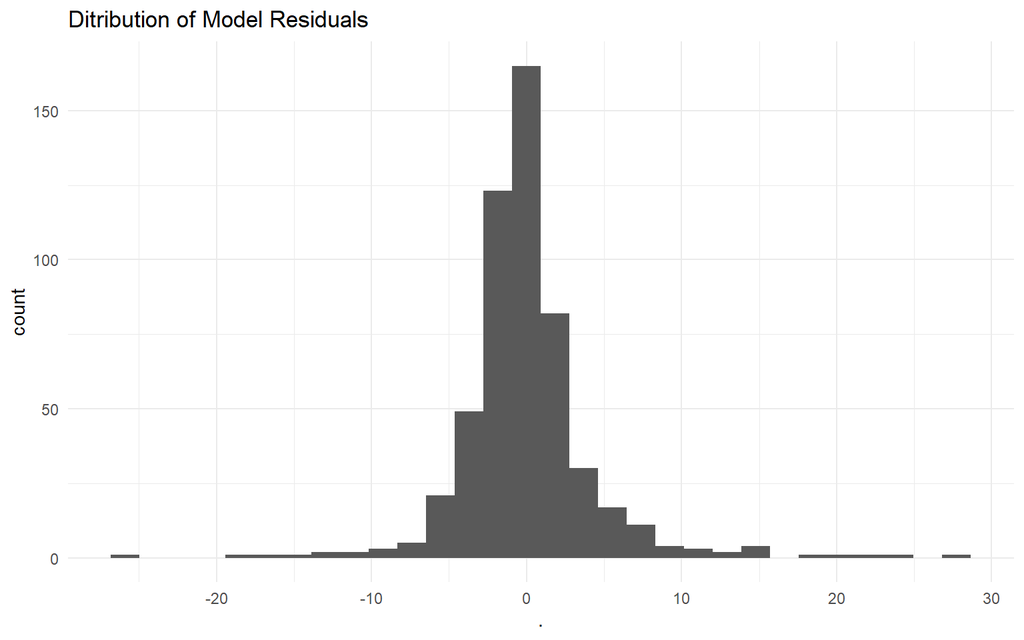

```r
ggplot(residuals(m1) %>%  as.data.frame(), aes(x = .))+
  geom_histogram()+
  ggtitle("Ditribution of Model Residuals")+
  theme_minimal()
```

#### 9.4.2.2 Gamma model

```r
m2 <- glmer(days ~
          subspecialty +
          insurance_type +
            age_category+
            District +
          central +
          gender +
          dow +
            ntransf +
          provider + (1|name),
               data = final5,
               family = Gamma(link=log),
               nAGQ = 1)

tab_model(m2)
```

|  | days |  |  |
| --- | --- | --- | --- |
| Predictors | Estimates | CI | p |
| (Intercept) | 17.05 | 6.46 – 44.99 | **<0.001** |
| subspecialty [Fem PM & RM] | 1.61 | 1.23 – 2.10 | **<0.001** |
| subspecialty [Mat-Fet Med] | 1.37 | 1.01 – 1.84 | **0.040** |
| subspecialty [Reprod End & Infert] | 1.98 | 1.35 – 2.89 | **<0.001** |
| insurance type [Medicaid] | 1.50 | 1.39 – 1.62 | **<0.001** |
| age category [40 to 49 years old] | 1.21 | 0.80 – 1.82 | 0.364 |
| age category [50 to 59 years old] | 1.29 | 0.86 – 1.95 | 0.219 |
| age category [60 years old or greater] | 1.30 | 0.84 – 2.01 | 0.241 |
| District [District II] | 0.86 | 0.55 – 1.36 | 0.531 |
| District [District III] | 1.00 | 0.65 – 1.54 | 0.983 |
| District [District IV] | 0.95 | 0.61 – 1.46 | 0.800 |
| District [District IX] | 0.95 | 0.58 – 1.57 | 0.841 |
| District [District V] | 0.84 | 0.53 – 1.32 | 0.449 |
| District [District VI] | 0.75 | 0.48 – 1.16 | 0.196 |
| District [District VII] | 0.87 | 0.52 – 1.43 | 0.574 |
| District [District VIII] | 0.97 | 0.60 – 1.58 | 0.904 |
| District [District XI] | 0.93 | 0.57 – 1.53 | 0.783 |
| District [District XII] | 0.97 | 0.52 – 1.80 | 0.911 |
| District [Missing] | 0.75 | 0.38 – 1.47 | 0.397 |
| central [No] | 1.02 | 0.90 – 1.15 | 0.749 |
| gender [Male] | 0.82 | 0.66 – 1.02 | 0.073 |
| dow [Tuesday] | 1.16 | 0.97 – 1.38 | 0.107 |
| dow [Wednesday] | 0.83 | 0.74 – 0.94 | **0.002** |
| dow [Thursday] | 0.75 | 0.65 – 0.87 | **<0.001** |
| dow [Friday] | 0.78 | 0.66 – 0.92 | **0.004** |
| ntransf [No transfers] | 0.67 | 0.50 – 0.89 | **0.007** |
| ntransf [One transfer] | 0.87 | 0.65 – 1.15 | 0.327 |
| ntransf [Two transfers] | 0.84 | 0.62 – 1.14 | 0.258 |
| provider [MD] | 0.64 | 0.30 – 1.39 | 0.261 |
| Random Effects |  |  |  |
| σ<sup>2</sup> | 0.15 |  |  |
| τ<sub>00</sub> <sub>name</sub> | 0.41 |  |  |
| ICC | 0.73 |  |  |
| N <sub>name</sub> | 354 |  |  |
| Observations | 532 |  |  |
| Marginal R<sup>2</sup> / Conditional R<sup>2</sup> | 0.169 / 0.774 |  |  |

#### 9.4.2.3 Generalizing Estimating Equation

```r
m3 <- geeglm(days ~
          subspecialty +
          insurance_type +
            age_category +
            District +
          central +
          gender +
          dow +
            ntransf +
          provider,
          data = final5,
          id = NPI,
          std.err = "san.se",
          family = poisson(link = log),
          scale.fix = FALSE
          )

tab_model(m3)
```

|  | days |  |  |
| --- | --- | --- | --- |
| Predictors | Incidence Rate Ratios | CI | p |
| (Intercept) | 22.96 | 7.30 – 72.21 | **<0.001** |
| subspecialty [Fem PM & RM] | 1.58 | 1.27 – 1.96 | **<0.001** |
| subspecialty [Mat-Fet Med] | 1.15 | 0.90 – 1.47 | 0.258 |
| subspecialty [Reprod End & Infert] | 2.75 | 1.94 – 3.89 | **<0.001** |
| insurance type [Medicaid] | 1.60 | 1.41 – 1.82 | **<0.001** |
| age category [40 to 49 years old] | 1.40 | 1.03 – 1.89 | **0.029** |
| age category [50 to 59 years old] | 1.37 | 1.03 – 1.82 | **0.032** |
| age category [60 years old or greater] | 1.50 | 1.07 – 2.09 | **0.018** |
| District [District II] | 0.76 | 0.52 – 1.09 | 0.139 |
| District [District III] | 0.95 | 0.67 – 1.34 | 0.760 |
| District [District IV] | 1.05 | 0.70 – 1.57 | 0.830 |
| District [District IX] | 0.95 | 0.62 – 1.46 | 0.817 |
| District [District V] | 1.02 | 0.65 – 1.60 | 0.941 |
| District [District VI] | 0.85 | 0.59 – 1.25 | 0.414 |
| District [District VII] | 0.85 | 0.59 – 1.24 | 0.395 |
| District [District VIII] | 0.99 | 0.69 – 1.41 | 0.939 |
| District [District XI] | 0.82 | 0.55 – 1.21 | 0.319 |
| District [District XII] | 0.83 | 0.47 – 1.48 | 0.530 |
| District [Missing] | 0.81 | 0.54 – 1.22 | 0.316 |
| central [No] | 1.16 | 0.97 – 1.39 | 0.109 |
| gender [Male] | 0.77 | 0.64 – 0.94 | **0.010** |
| dow [Tuesday] | 1.05 | 0.75 – 1.48 | 0.765 |
| dow [Wednesday] | 0.83 | 0.68 – 1.01 | 0.064 |
| dow [Thursday] | 0.71 | 0.54 – 0.93 | **0.012** |
| dow [Friday] | 0.55 | 0.43 – 0.70 | **<0.001** |
| ntransf [No transfers] | 0.97 | 0.67 – 1.40 | 0.870 |
| ntransf [One transfer] | 0.90 | 0.61 – 1.33 | 0.610 |
| ntransf [Two transfers] | 1.05 | 0.62 – 1.76 | 0.859 |
| provider [MD] | 0.46 | 0.18 – 1.19 | 0.109 |
| N <sub>NPI</sub> | 354 |  |  |
| Observations | 532 |  |  |

### 9.4.3 Effects

We quickly look at some effect using the initial poisson mixed model.

#### 9.4.3.1 Insurance Type

Estimates with confidence interval of the number of days of waiting time.

```r
emmeans(lmmodel1, ~ insurance_type, type = "response",
        nuisance = c("District","central","gender",
                     "ntransf","provider"))
```

```
##  insurance_type    rate   SE  df asymp.LCL asymp.UCL
##  Blue Cross/Shield 15.9 2.33 Inf      11.9      21.2
##  Medicaid          22.9 3.42 Inf      17.1      30.6
##
## Results are averaged over the levels of: 5 nuisance factors, subspecialty, age_category, dow
## Confidence level used: 0.95
## Intervals are back-transformed from the log scale
```

We can show the effect in a graph. Notice that these are **model adjusted means**, that is, it is not just average waiting time, but the average waiting time controlled for the other variable in the model.

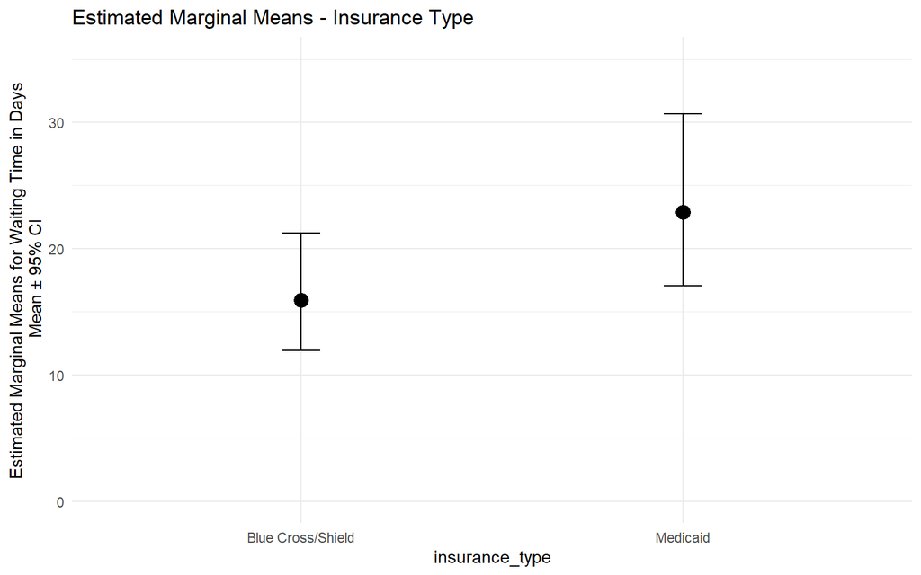

```r
edata <- emmeans(lmmodel1, ~ insurance_type, type = "response",
                 nuisance = c("District","central","gender",
                     "ntransf","provider")) %>%
  as.data.frame()

ggplot(edata, aes(x = insurance_type, y = rate))+
  geom_point(size = 2, stroke = 2)+
  geom_errorbar(aes(ymin = asymp.LCL, ymax = asymp.UCL), width = 0.1)+
  ylim(0,35)+
  ggtitle("Estimated Marginal Means - Insurance Type")+
  ylab("Estimated Marginal Means for Waiting Time in Days\n Mean ± 95% CI")+
  theme_minimal()
```

#### 9.4.3.2 Subspecialty

Subspecialty is significant as we see in the ANOVA table.

```r
car::Anova(lmmodel1, type = 3)
```

```
## Analysis of Deviance Table (Type III Wald chisquare tests)
##
## Response: days
##                  Chisq Df Pr(>Chisq)
## (Intercept)    60.8749  1  6.082e-15 ***
## subspecialty   37.5395  3  3.538e-08 ***
## insurance_type 98.7083  1  < 2.2e-16 ***
## age_category    4.3740  3    0.22381
## District        5.6314 11    0.89679
## central         0.3167  1    0.57363
## gender          4.7852  1    0.02871 *
## dow            27.8796  4  1.319e-05 ***
## ntransf        11.1946  3    0.01072 *
## provider        2.8823  1    0.08956 .
## ---
## Signif. codes:  0 '***' 0.001 '**' 0.01 '*' 0.05 '.' 0.1 ' ' 1
```

Estimates with confidence interval of the number of days of waiting time.

```r
emmeans(lmmodel1, pairwise~ subspecialty, type = "response",
        adjust = "bon",nuisance = c("District","central","gender",
                     "ntransf","provider"))
```

```
## $emmeans
##  subspecialty        rate   SE  df asymp.LCL asymp.UCL
##  Gyn Onc             13.1 2.13 Inf      9.53      18.0
##  Fem PM & RM         20.8 3.28 Inf     15.27      28.3
##  Mat-Fet Med         17.2 2.69 Inf     12.68      23.4
##  Reprod End & Infert 28.2 5.22 Inf     19.66      40.6
##
## Results are averaged over the levels of: 5 nuisance factors, insurance_type, age_category, dow
## Confidence level used: 0.95
## Intervals are back-transformed from the log scale
##
## $contrasts
##  contrast                            ratio     SE  df null z.ratio p.value
##  Gyn Onc / Fem PM & RM               0.630 0.0610 Inf    1  -4.769  <.0001
##  Gyn Onc / (Mat-Fet Med)             0.761 0.0845 Inf    1  -2.457  0.0840
##  Gyn Onc / Reprod End & Infert       0.464 0.0665 Inf    1  -5.358  <.0001
##  Fem PM & RM / (Mat-Fet Med)         1.208 0.1270 Inf    1   1.795  0.4362
##  Fem PM & RM / Reprod End & Infert   0.736 0.1017 Inf    1  -2.216  0.1602
##  (Mat-Fet Med) / Reprod End & Infert 0.610 0.0905 Inf    1  -3.333  0.0051
##
## Results are averaged over the levels of: 5 nuisance factors, insurance_type, age_category, dow
## P value adjustment: bonferroni method for 6 tests
## Tests are performed on the log scale
```

We can show the effect in a graph.

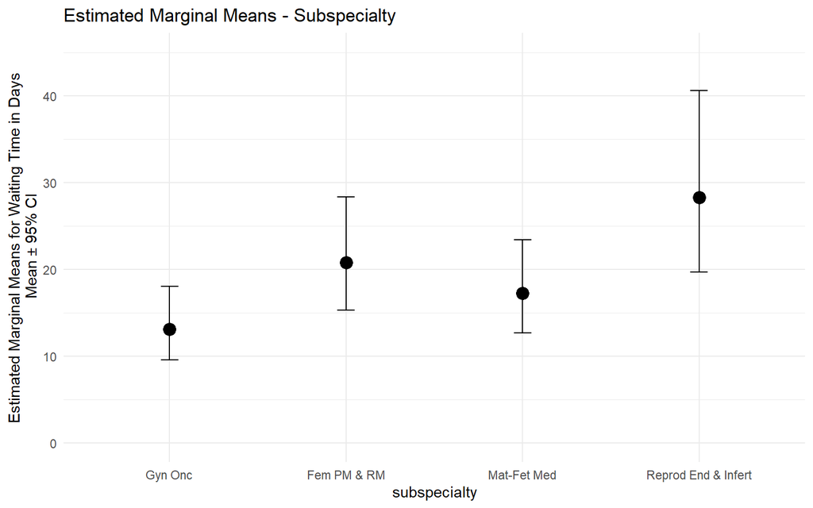

```r
edata <- emmeans(lmmodel1, ~ subspecialty, type = "response",
                 nuisance = c("District","central","gender",
                     "ntransf","provider")) %>%
  as.data.frame()

ggplot(edata, aes(x = subspecialty, y = rate))+
  geom_point(size = 2, stroke = 2)+
  geom_errorbar(aes(ymin = asymp.LCL, ymax = asymp.UCL), width = 0.1)+
  ylim(0,45)+
  ggtitle("Estimated Marginal Means - Subspecialty")+
  ylab("Estimated Marginal Means for Waiting Time in Days\n Mean ± 95% CI")+
  theme_minimal()
```

#### 9.4.3.3 Day of the Week

DOW is significant.

Estimates with confidence interval of the number of days of waiting time.

```r
car::Anova(lmmodel1, type = 3)
```

```
## Analysis of Deviance Table (Type III Wald chisquare tests)
##
## Response: days
##                  Chisq Df Pr(>Chisq)
## (Intercept)    60.8749  1  6.082e-15 ***
## subspecialty   37.5395  3  3.538e-08 ***
## insurance_type 98.7083  1  < 2.2e-16 ***
## age_category    4.3740  3    0.22381
## District        5.6314 11    0.89679
## central         0.3167  1    0.57363
## gender          4.7852  1    0.02871 *
## dow            27.8796  4  1.319e-05 ***
## ntransf        11.1946  3    0.01072 *
## provider        2.8823  1    0.08956 .
## ---
## Signif. codes:  0 '***' 0.001 '**' 0.01 '*' 0.05 '.' 0.1 ' ' 1
```

```r
emmeans(lmmodel1, ~ dow, type = "response",
        nuisance = c("District","central","gender",
                     "ntransf","provider"))
```

```
##  dow       rate   SE  df asymp.LCL asymp.UCL
##  Monday    22.0 3.36 Inf      16.3      29.6
##  Tuesday   22.7 3.58 Inf      16.7      31.0
##  Wednesday 18.1 2.66 Inf      13.5      24.1
##  Thursday  17.1 2.58 Inf      12.7      23.0
##  Friday    16.4 2.51 Inf      12.1      22.1
##
## Results are averaged over the levels of: 5 nuisance factors, subspecialty, insurance_type, age_category
## Confidence level used: 0.95
## Intervals are back-transformed from the log scale
```

We can show the effect in a graph.

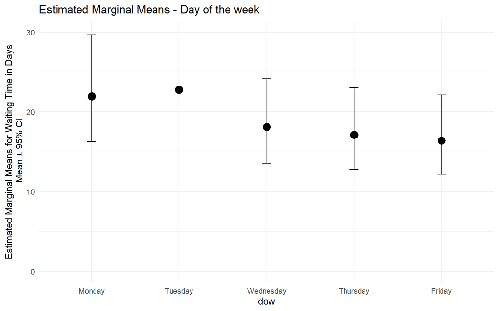

```r
edata <- emmeans(lmmodel1, ~ dow, type = "response",
                 nuisance = c("District","central","gender",
                     "ntransf","provider")) %>%
  as.data.frame()

ggplot(edata, aes(x = dow, y = rate))+
  geom_point(size = 2, stroke = 2)+
  geom_errorbar(aes(ymin = asymp.LCL, ymax = asymp.UCL), width = 0.1)+
  ylim(0,30)+
  ggtitle("Estimated Marginal Means - Day of the week")+
  ylab("Estimated Marginal Means for Waiting Time in Days\n Mean ± 95% CI")+
  theme_minimal()
```

#### 9.4.3.4 Gender

Gender is significant. So we take a look at its effect as well.

```r
car::Anova(lmmodel1, type = 3)
```

```
## Analysis of Deviance Table (Type III Wald chisquare tests)
##
## Response: days
##                  Chisq Df Pr(>Chisq)
## (Intercept)    60.8749  1  6.082e-15 ***
## subspecialty   37.5395  3  3.538e-08 ***
## insurance_type 98.7083  1  < 2.2e-16 ***
## age_category    4.3740  3    0.22381
## District        5.6314 11    0.89679
## central         0.3167  1    0.57363
## gender          4.7852  1    0.02871 *
## dow            27.8796  4  1.319e-05 ***
## ntransf        11.1946  3    0.01072 *
## provider        2.8823  1    0.08956 .
## ---
## Signif. codes:  0 '***' 0.001 '**' 0.01 '*' 0.05 '.' 0.1 ' ' 1
```

```r
emmeans(lmmodel1, ~ gender, type = "response",
        nuisance = c("District","central",
                     "ntransf","provider"))
```

```
##  gender rate   SE  df asymp.LCL asymp.UCL
##  Female 20.8 3.19 Inf      15.4      28.1
##  Male   17.5 2.64 Inf      13.0      23.5
##
## Results are averaged over the levels of: 4 nuisance factors, subspecialty, insurance_type, age_category, dow
## Confidence level used: 0.95
## Intervals are back-transformed from the log scale
```

We can show the effect in a graph.

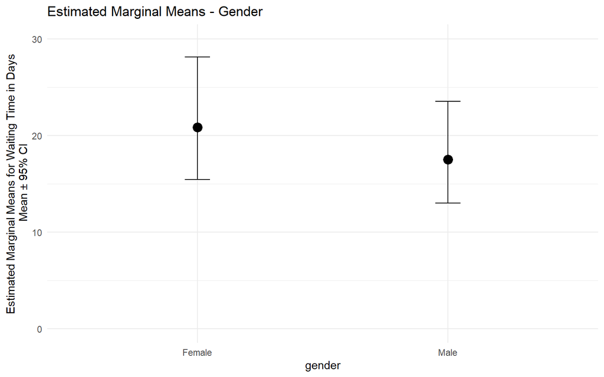

```r
edata <- emmeans(lmmodel1, ~ gender, type = "response",
                 nuisance = c("District","central",
                     "ntransf","provider")) %>%
  as.data.frame()

ggplot(edata, aes(x = gender, y = rate))+
  geom_point(size = 2, stroke = 2)+
  geom_errorbar(aes(ymin = asymp.LCL, ymax = asymp.UCL), width = 0.1)+
  ylim(0,30)+
  ggtitle("Estimated Marginal Means - Gender")+
  ylab("Estimated Marginal Means for Waiting Time in Days\n Mean ± 95% CI")+
  theme_minimal()
```